# Improvements Needed

Maarten J. Bijlsma

2023-03-27

Cancer Forecasting Methodology

Cancer Forecasts and Projections

Cancer is a leading cause of death, responsible for nearly [1 in 6 deaths worldwide](https://www.who.int/news-room/fact-sheets/detail/cancer). Cancer requires specialized care. As it takes time to train medical personnel and build capacity, it is paramount to know well in advance what future cancer incidence will be.

Various methods exist to gain insight into future cancer incidence. First, it is useful to make a distinction between forecasting and projection. Forecasting intends to predict the future based on current and past information (“the most likely future, given what we know”). Projections explore a “what if” scenario (“What would happen with cancer if we assume that a potential driver of this cancer is decreased?”). The boundary between forecasts and projections may not always be clear. Some projects may involve elements of both. However, in any good statistical project, the methods should stem from the research aim; for a projection it makes sense to determine the effect of e.g. a driver (smoking) on cancer, so that the impact of potential future smoking prevalence scenarios on cancer can be investigated. For a pure forecast, this would be less sensible unless future smoking prevalence is known; since this is extremely unlikely, this would only add additional uncertainty to a forecast as it means first smoking would have to be forecasted and then future cancer can be estimated.

Age, Period and Cohort Dimensions: “theory”

In this document, I focus on forecasting. Pure cancer forecasts tend to be trend extrapolations, though some fundamental ‘driver’ information is known and used. Specifically, cancer incidence happens more at some ages than at others, and may affect some sexes more than others. Since demographic forecasts (of e.g. future age distributions) tend to be very reliable, it is common to take age and sex into account. In other words, we will try to model (for men and women separately) the ‘effect’ of age on cancer incidence, and a timetrend. The timetrend can then be extrapolated, and the age ‘effect’ can be used together with the future age distribution to determine changes in future cancer incidence ‘caused by’ changes in the future age distribution. I write ‘effect’ and ‘caused’ within quotation marks because age is not a manipulable exposure. The debate is not finished on whether nonmanipulable exposures can be ‘causes’ of things and whether they can therefore have ‘effects’ or not. However, what we are looking at is that higher or lower cancer risks are associated with age due to various biological, sociological and environmental factors that are associated with time since birth (‘age’) in some diffuse way. However, in the literature, they speak of age ‘effects’ (and, period and cohort ‘effects’). This is an unfortunate misnomer, but it has stood the test of time. In much the same way, the timetrend is not a cause of anything, but is some sort of proxy of societal and environmental developments that follow a (non-)linear trend and which we believe might continue onwards into the future in some way. Sometimes so-called ‘period effects’ are also modelled, which can represent the same diffuse factors associated with calendar time. However, it might not always be sensible to model period effects for cancer incidence forecasting, next to a time trend. I will explain that later, so I will not dwell on period effects further here.

However, age and period are not the only proxies. Some underlying drivers of cancer, such as smoking, are strongly related to ‘birth cohort’ (time period of birth); individuals who grew up in a particular time period, and were therefore exposed to the same macro-level formative experiences, share certain characteristics. Those characteristics might stick with that cohort, even long after the period of exposure has passed. Hence, birth cohort might be predictive of particular outcomes, even when age and period are taken into account. For example, individuals born between 1920 and 1940 had much higher levels of ever-smoking than later generations. Birth cohort, therefore, can be predictive of lung cancer incidence.

Age Period Cohort (APC) Models and the Linear Dependency Problem

Therefore, one of the most common models for forecasting cancer is a model where age, period, and cohort, are covariates. Cancer incidence will be the outcome, which is frequently a count. Therefore, a Poisson distribution is often assumed. The canonical link-function for a Poisson model is the log-link. The size of the population at risk (N) likely also changes over time, so we also want to take into account population at risk. Hence, we would like to model:

$log(\frac{y}{N}) = \mu + \alpha \times a + \beta \times p + \gamma \times c \Rightarrow log(y) = \mu + \alpha \times a + \beta \times p + \gamma \times c + log(N)$

where $y$ is cancer incidence, $a$, $p$ and $c$ refers to age, period and cohort, $\mu$ is some intercept, the $\alpha$ are the age effects, the $\beta$ the period effects, and the $\gamma$ the cohort effects. The $N$ is the population at risk; this is entered as a so-called ‘offset’ variable (a variable considered to be a known constant). I’m leaving out subscripts to refer to the values of particular individuals or subscripts for the coefficients (as one may estimate multiple age parameters, and so forth).

However, as well know, if you know what someone’s birthday is, and you know what today’s date is, then you also know exactly how old they are. We have Age = Period - Cohort. In other words, there is a linear dependency between the age, period and cohort dimensions. This is a problem.

Imagine fitting this model, where $y$ is an outcome and $x_{1}$ is a covariate:

$y_{i} = \beta_{0} + \beta_{1} \times x_{1} + \beta_{2} \times x_{1} + e_{i}$

That, is, we add $x_{1}$ to the model twice. This is a silly thing to do, because you are using the same information twice. The second $x_{1}$ does not add any new information. If we force a computer to estimate this model, it will either not ‘solve’ since we do not get unique solution, or in many packages the second $x_{1}$ will be thrown out of the model and $\beta_{2}$ will not be estimated (but we get estimates for the remaining parameters).

In the case of the APC model, we have a similar problem. Since A = P - C, we are effectively entering the same information twice. Let’s [substitute P = A + C into the model](https://link.springer.com/article/10.1007/s13524-017-0562-6).

$\mu + \alpha \times a + \beta \times p + \gamma$

$= \mu + \alpha \times a + \beta \times (a + c) + \gamma$

$= \mu + (\alpha + \beta) \times a + (\gamma + \beta) \times c$

This shows that $\beta$ effectively is part of model that includes age and cohort already, though its influence changes the estimated age and cohort effects. In APC jargon, it is argued that the third dimension biases the other two dimensions, though the term ‘bias’ here is ill-defined; it is an identification problem, not a statistical inferential bias, and a definition of bias in the causal sense would at the very least require very careful wording since age, period and cohort are not manipulable exposures (if it is doable at all). What is meant, but virtually never written down explicitly, is that the age-pattern of cancer incidence will shift over time due birth cohorts reaching older ages. Hence, the underlying belief appears to be that there is some ‘true’ age response curve that is distorted by these cohort effects. Hence, we need to filter out these cohort effects in some way. In truth, even at a theoretical etiological (non-statistical) level, age, period and cohort effects are inseparably intertwined because both are vague proxies of a multitude of biological, sociological and environmental factors that are the true drivers of cancer. Since they cannot even be separated outside of our data and models, we should not expect the model to separate them either. This was also the conclusion of Fienberg in the [December 2013 issue of Demography](https://link.springer.com/journal/13524/volumes-and-issues/50-6?page=1).

However, even if we cannot in a meaningful (causal) way separate these three effects, we might still improve our predictive potential by trying to include all three dimensions. Since we are doing forecasting, this is worth a try.

The aforementioned problem is referred to as the ‘linear dependency problem’ or the ‘linear identification problem’. The solution, therefore, is to try to identify non-linear effects. For example, conditional on age and period, one might still be able to identify ‘non-linear’ cohort effects. Including such effects might improve the predictive potential of our model. What do we mean by non-linear effects?

Essentially, we could choose to decompose our cancer incidence into: - Age effects - Linear timetrend (referred to as ‘drift’ in APC jargon) - Non-linear period effects (deviations from the linear timetrend that occur in calendar time) - Non-linear cohort effects (deviations from the linear timetrend that occur in time-since-birth)

Many different APC models have been proposed that attempt to do something like this. See for example [this paper](https://pubmed.ncbi.nlm.nih.gov/31462469/) and [this paper](https://www.jstor.org/stable/26408090).

In this document, I will focus on the so-called ‘age-period-cohort multiple classification model’ (APCMC model). The reason for this, is that a commonly used cancer forecasting software, [Nordpred](https://www.kreftregisteret.no/en/Research/Projects/Nordpred/Nordpred-software/), is such an APCMC model. I have often used APCMC models, which I usually refer to as a Clayton & Schifflers APC model, after seminal work by these authors. You can find some of my papers that include work with models like this [here](https://www.sciencedirect.com/science/article/abs/pii/S089543561200162X), and [here](https://pubmed.ncbi.nlm.nih.gov/35944161/). Hence, I am quite familiar with these models.

For cancer forecasting, I believe we can do better than using an APCMC model. This document will focus on some of the ways in which we can improve on the Nordpred software. This is not a criticism of Nordpred. If anything, it is an homage, since it is wonderful and easy to use software that has stood the test of time. However, with advances in statistical estimation software, we can now improve upon Nordpred. Let’s first zoom in a little bit deeper on what what age-period-cohort multiple classifcation (APCMC) models do.

APCMC models: a demonstration of effects of constraints

What does an APCMC model do? It achieves the decomposition into drift, age, non-linear period, and non-linear cohort effects by modelling age, period and cohort as categorical variables and placing two reference categories on period and on cohort. By placing two reference categories on period, we are effectively saying that these two periods have equal risk (conditional on age and period) of the outcome. The same holds for setting two cohorts to be equal. This is a so-called ‘untestable assumption’ because we impose this constraint; the data cannot tell us if the constraint is true. However, the constraint will frequently have a strong effect on the drift (linear time trend) parameter. Namely, if e.g. period 2010 has a higher incidence than 1990 (conditional on age and cohort), and we set these two periods to be equal, then a positive slope gets attributed to the drift parameter. This is as intended. The outcome might vary strongly over calendar time. So a sudden spike or valley in a particular year might strongly pull the drift up or down. Also, our cohort constraints will assign trend to the drift in much the same way; in theory the drift is made up of the sum of ‘true’ (age, period and cohort attributable) linear trends over time, but we can only identify from the data one un-decomposable trend. I write ‘in theory’ because as described earlier, age, period, and cohort are poorly defined proxies for some of the same phenomena on a time axis. Now, sudden spikes are usually detectable even in descriptive data. So this might not be a problem. But things become more difficult if the period and cohort dimensions exhibit curvature. Let’s fit such a model using simulated data, so that we can know what the ‘true’ age, period and cohort ‘effects’ are.

```r
library(caret)
```

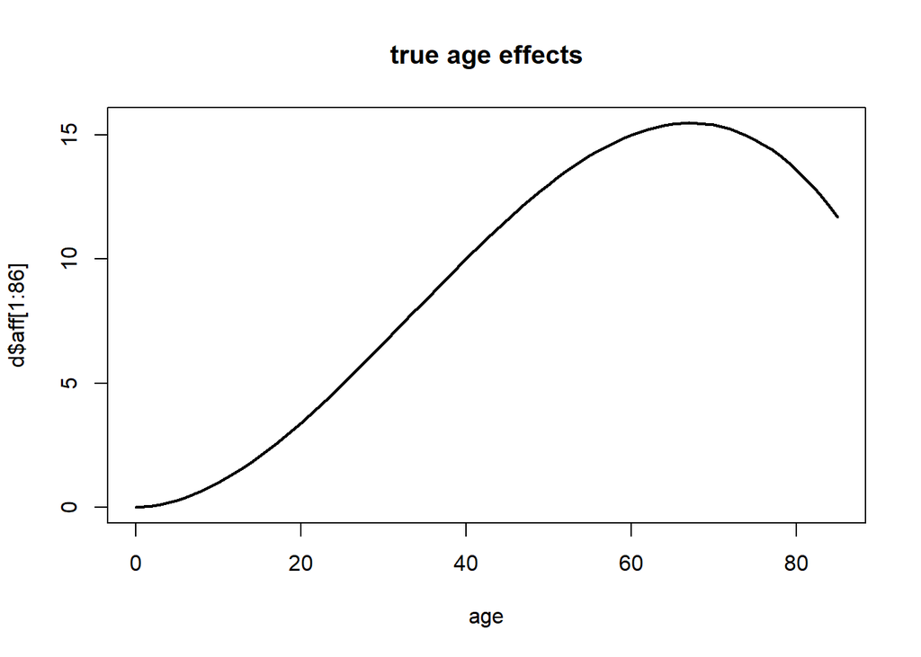

```r
library(MASS)

# simulation example, where 'true' effects are known
set.seed(1)
a <- 0:85
p <- 1990:2020
d <- data.frame(expand.grid(a,p))
names(d) <- c('a','p')
d$c <- d$p - d$a
# set age period and cohort effects
# (let's use an identity link, to keep things simple for now)
peff <- runif(length(p))*15+0.5*(p-1990)
d$aff <- d$a*0.010 + d$a^2*0.010 - d$a^3*0.00010
d$peff <- rep(peff,each=length(a))
d$ceff <- 10*cos((d$c-1905)/25)
# add them together with random error to produce y:
d$y <- d$aff + d$peff + d$ceff + rnorm(length(d$a))

# the 'true' age, period and cohort effects are:
plot(d$a[1:86],d$aff[1:86], xlab='age',main='true age effects',type='l',lwd=2)
```

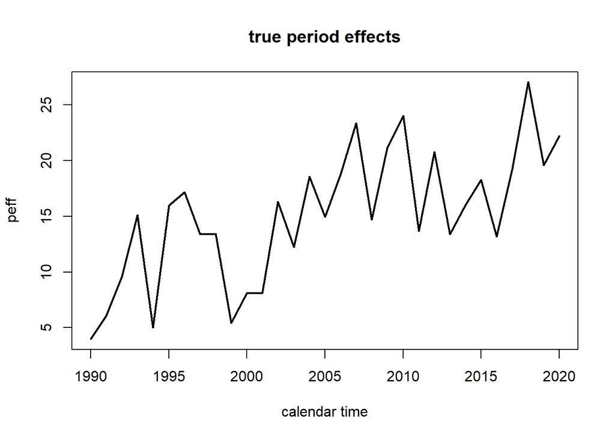

```r
plot(p,peff, xlab='calendar time',main='true period effects', type='l', lwd=2)
```

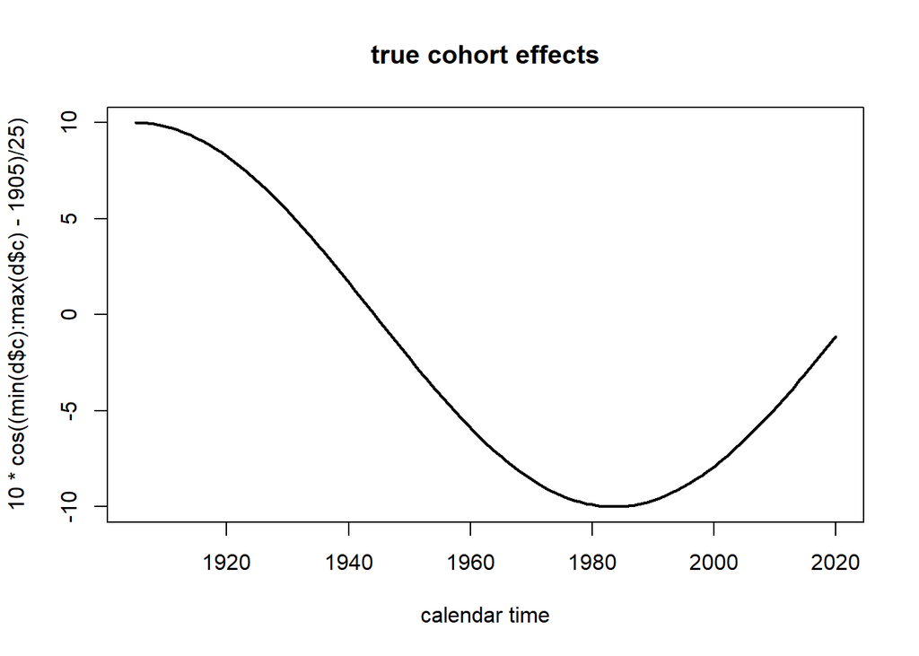

```r
plot(min(d$c):max(d$c),10*cos((min(d$c):max(d$c)-1905)/25), xlab='calendar time',main='true cohort effects',type='l',lwd=2)
```

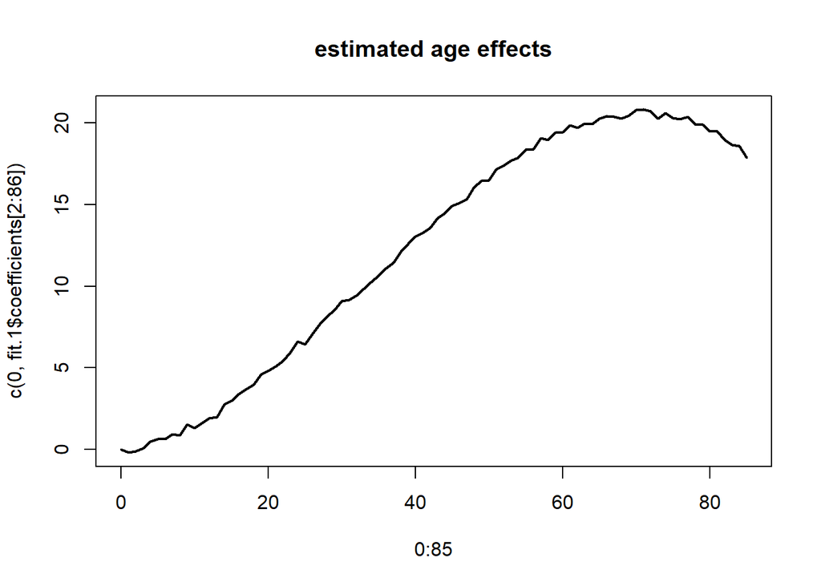

```r
# now let's estimate the age, period and cohort effect using categorical predictors
dc <- d
dc$pcode <- dc$p-1989
dc$a <- factor(dc$a)
dc$p <- factor(dc$p)
dc$c <- factor(dc$c)

dv <- dummyVars(y ~ a + p + c,
              data=dc)
dc <- cbind(dc,predict(dv, newdata = dc))

# showing all the predictors in the model for the sake of transparency:
fit.1 <- lm(y ~
        # a.0 +
        +a.1    +a.2    +a.3    +a.4    +a.5    +a.6    +a.7    +a.8
        +a.9    +a.10   +a.11   +a.12   +a.13   +a.14   +a.15   +a.16
        +a.17   +a.18   +a.19   +a.20   +a.21   +a.22   +a.23   +a.24
        +a.25   +a.26   +a.27   +a.28   +a.29   +a.30   +a.31   +a.32
        +a.33   +a.34   +a.35   +a.36   +a.37   +a.38   +a.39   +a.40
        +a.41   +a.42   +a.43   +a.44   +a.45   +a.46   +a.47   +a.48
        +a.49   +a.50   +a.51   +a.52   +a.53   +a.54   +a.55   +a.56
        +a.57   +a.58   +a.59   +a.60   +a.61   +a.62   +a.63   +a.64
        +a.65   +a.66   +a.67   +a.68   +a.69   +a.70   +a.71   +a.72
        +a.73   +a.74   +a.75   +a.76   +a.77   +a.78   +a.79   +a.80
        +a.81   +a.82   +a.83   +a.84   +a.85
        #+p.1990
        +p.1991 +p.1992
        +p.1993 +p.1994 +p.1995 +p.1996 +p.1997 +p.1998 +p.1999 +p.2000
        +p.2001 +p.2002 +p.2003 +p.2004 +p.2005 +p.2006 +p.2007 +p.2008
        +p.2009 +p.2010 +p.2011 +p.2012 +p.2013 +p.2014 +p.2015 +p.2016
        +p.2017 +p.2018 +p.2019
        # +p.2020
        #+ c.1905
        +c.1906 +c.1907 +c.1908
        +c.1909 +c.1910 +c.1911 +c.1912 +c.1913 +c.1914 +c.1915 +c.1916
        +c.1917 +c.1918 +c.1919 +c.1920 +c.1921 +c.1922 +c.1923 +c.1924
        +c.1925 +c.1926 +c.1927 +c.1928 +c.1929 +c.1930 +c.1931 +c.1932
        +c.1933 +c.1934 +c.1935 +c.1936 +c.1937 +c.1938 +c.1939 +c.1940
        +c.1941 +c.1942 +c.1943 +c.1944 +c.1945 +c.1946 +c.1947 +c.1948
        +c.1949 +c.1950 +c.1951 +c.1952 +c.1953 +c.1954 +c.1955 +c.1956
        +c.1957 +c.1958 +c.1959 +c.1960 +c.1961 +c.1962 +c.1963 +c.1964
        +c.1965 +c.1966 +c.1967 +c.1968 +c.1969 +c.1970 +c.1971 +c.1972
        +c.1973 +c.1974 +c.1975 +c.1976 +c.1977 +c.1978 +c.1979 +c.1980
        +c.1981 +c.1982 +c.1983 +c.1984 +c.1985 +c.1986 +c.1987 +c.1988
        +c.1989 +c.1990 +c.1991 +c.1992 +c.1993 +c.1994 +c.1995 +c.1996
        +c.1997 +c.1998 +c.1999 +c.2000 +c.2001 +c.2002 +c.2003 +c.2004
        +c.2005 +c.2006 +c.2007 +c.2008 +c.2009 +c.2010 +c.2011 +c.2012
        +c.2013 +c.2014 +c.2015 +c.2016 +c.2017 +c.2018 +c.2019 + # c.2020
        pcode # final pcode is continuous, and a way to measure drift
        , data=dc)
# here, the first age category, as well as the first and last period categories
# and the first and last cohort categories, are set to the ref
# later, I will refer to this version of constraints as 'extremes'.

plot(0:85,c(0,fit.1$coefficients[2:86]), main='estimated age effects',type='l',lwd=2)
```

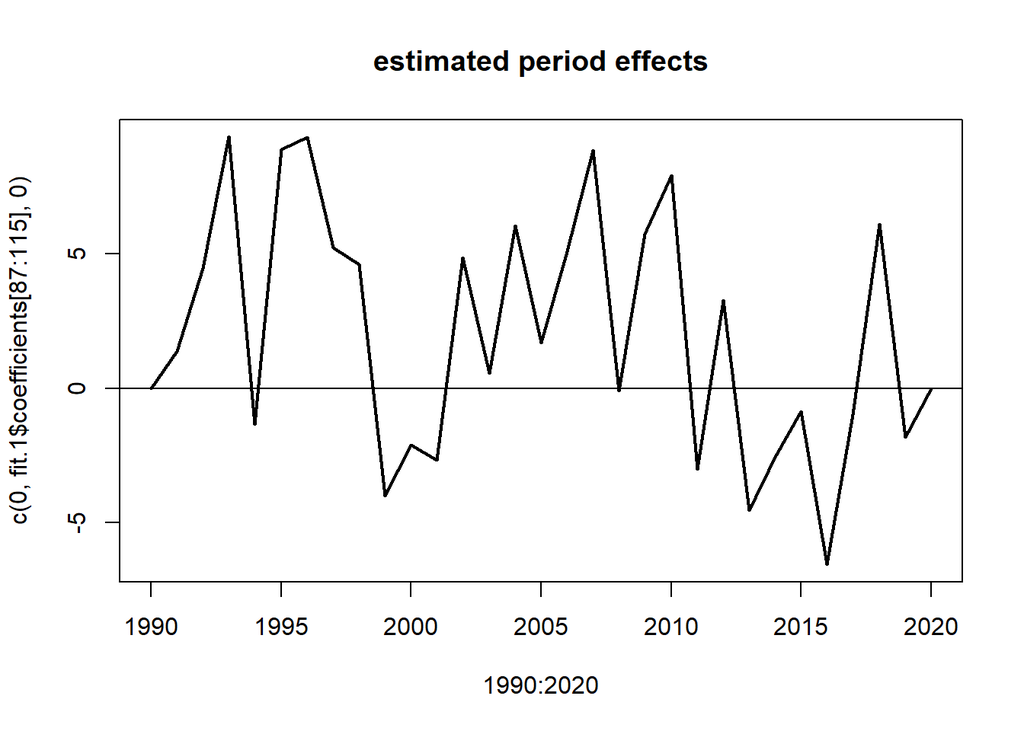

```r
plot(1990:2020,c(0,fit.1$coefficients[87:115],0), main='estimated period effects',type='l',lwd=2)
abline(h=0)
```

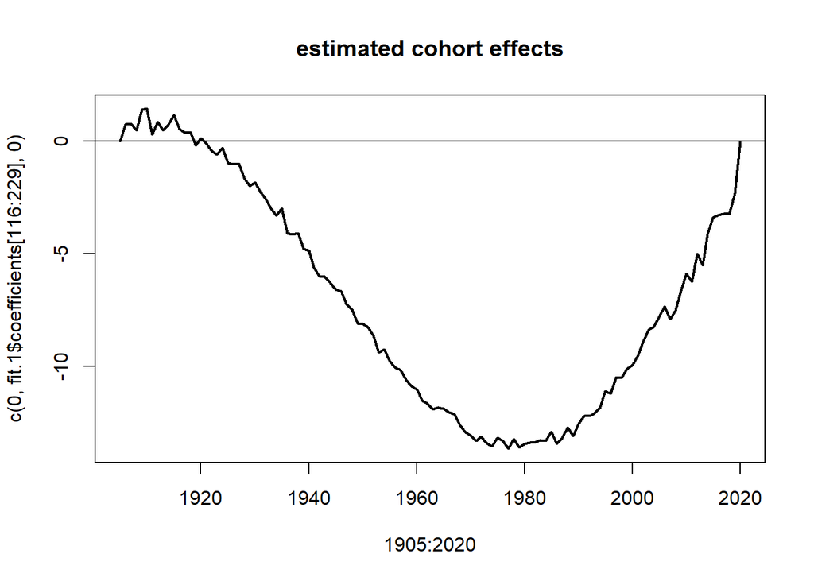

```r
plot(1905:2020,c(0,fit.1$coefficients[116:229],0), main='estimated cohort effects',type='l',lwd=2)
abline(h=0)
```

What you can see when you compare these figures to their ‘true’ values is that they capture the ‘non-linear’ part quite well. That is, the part that deviates from a linear trend that one could draw through the true effect curve. For example, in the ‘true’ cohort curve, the effect starts at 10 for the oldest birth cohort and then declines. Around the 1980 birth cohort it starts to recuperate, but the recuperation is far from complete by the time we reach the 2020 birth cohort. In our estimated birth cohort effects, however, the line ends up pretty much back at the start. For the period effects, this story is much the same: we essentially see variance around a horizontal line.

Of course, we do have information on the linear trend in the form of the pcode parameter. However, this parameter contains *all* of the linear trend information. We do not know which part is attributable to period and which to cohort.

Now, let’s play with the cohort constraints. I will keep my first reference as the earliest cohort, but move my second reference from the latest cohort to one slightly before that, and then slightly before that, and so forth. This causes the ‘drift’ parameter (estimated for the pcode predictor) to change. Subsequently, what is considered a non-linear deviation from this drift will also change. What we will see is a type of ‘rotation’ in the estimated age, period and cohort effects.

```r
# instead of copying and pasting a massive list of covariates, let's make
# a dataset with just the covariates we want as predictors
dc$a <- dc$p <- dc$c <- dc$aff <- dc$peff <- dc$ceff <- NULL
# in all these datasets we want a.0, p.1990, p.2020 and c.1905 as references
dc$a.0 <- dc$p.1990 <- dc$p.2020 <- dc$c.1905 <- NULL
# now we make different sets with different final cohorts as references
dc.c2020 <- dc.c2017 <- dc.c2014 <- dc.c2011 <- dc.c2008 <- dc.c2005 <- dc
dc.c2020$c.2020 <- NULL
dc.c2017$c.2017 <- NULL
dc.c2014$c.2014 <- NULL
dc.c2011$c.2011 <- NULL
dc.c2008$c.2008 <- NULL
dc.c2005$c.2005 <- NULL

# now let's fit the models
fit.2020 <- lm(y ~ ., data=dc.c2020)
fit.2017 <- lm(y ~ ., data=dc.c2017)
fit.2014 <- lm(y ~ ., data=dc.c2014)
fit.2011 <- lm(y ~ ., data=dc.c2011)
fit.2008 <- lm(y ~ ., data=dc.c2008)
fit.2005 <- lm(y ~ ., data=dc.c2005)

# now let's look at the cohort effects from each of these models
```

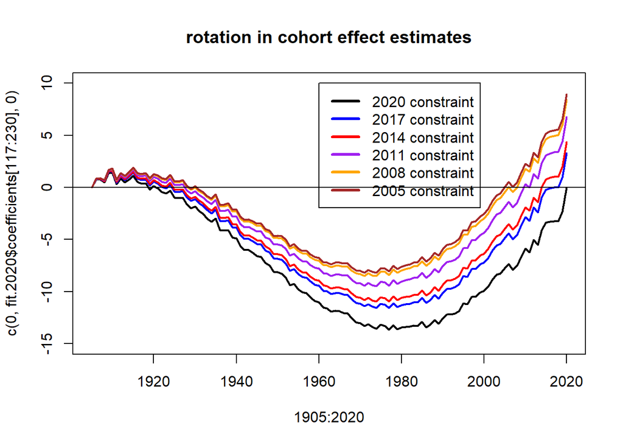

However, this rotation doesn’t just happen for the cohort dimension (even though that is where I changed the references). It also happens for the age dimension; remember, the drift is shared linearity between age, period and cohort. So constraints on one dimension affect the other two as well.

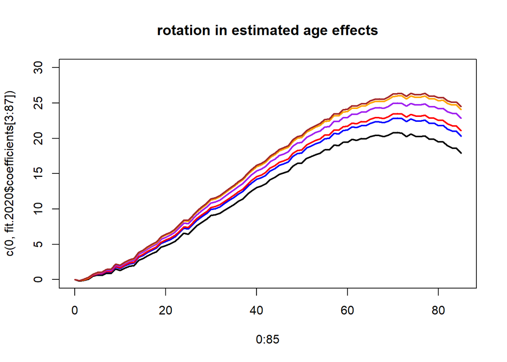

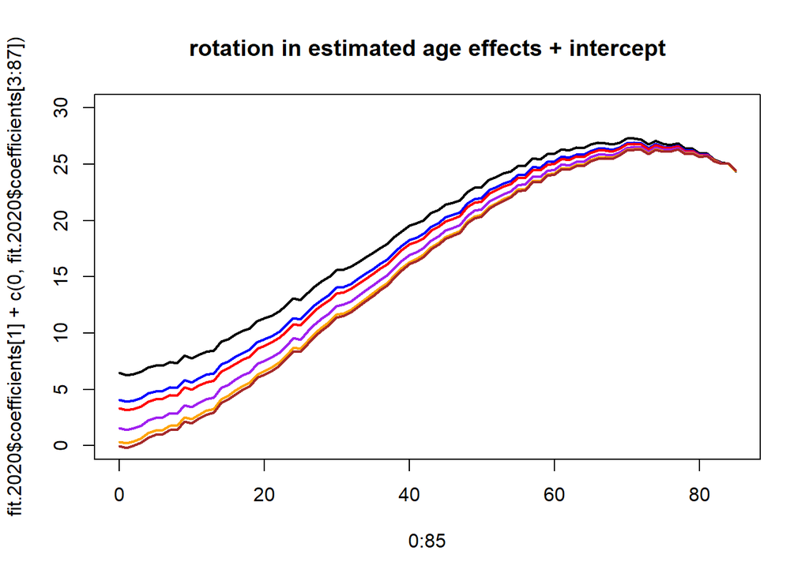

The reason, of course, is because the drift parameter is changed each time. Let’s look at the shift in drift parameter:

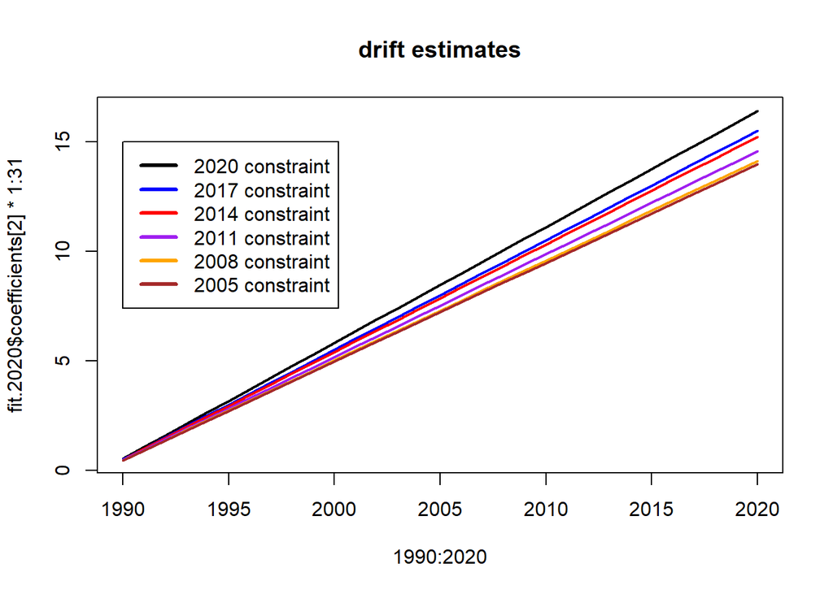

But what about the period dimension? Well, period in our current parameterization has two reference categories. Because we’ve ‘pinned’ it down in this way, it cannot rotate. So they’re all on top of each other. I add a tiny bit of jitter to the graph below to demonstrate this.

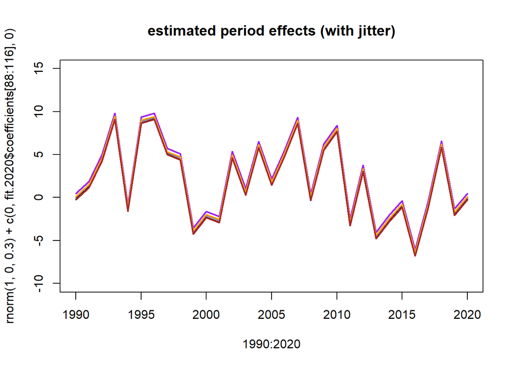

What happens if we add the drift and the period estimates together?

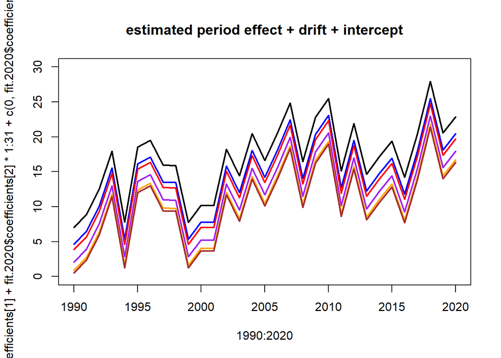

The estimates with drift added look more like the ‘true’ period effects. However, the true period effects experience a more steep trend over time. The reason why this one is less steep, is because cohort also contributes a linear trend to the drift parameter. The cohort part of the drift is negative, while the period part is positive. So the sum of both is a less steep drift. I’ve added the intercept as well, to show that the changes in reference, by definition, also result in a change in intercept.

Improvements over the APCMC model for Cancer forecasting

Problem list

There are a number of problems with using a classical implementation of the APCMC model for forecasting cancer incidence. By addressing these problems, we can make more truthful and more informative forecasts. The problems are:

1. Choice of Period and Cohort constraints is arbitrary.
2. Extreme cohort constraints result in higher estimator variance than necessary.
3. Variance of the outcome variable is not correctly estimated: a. Poisson distributions set the variance equal to the mean; b. Non-linear period effects filter away true variance on the time axis.
4. Both the log-link and the power5 link can result in extreme predictions when extrapolated.
5. Poisson models do not deal well with structural 0s.
6. Incidence is estimated per cancer type, and per cancer stage, separately. However, we know that trends between cancers and between stages are not independent.
7. Standard GLMs do not perform well when estimating for small areas.
8. Uncertainty in GLMs when used for forecasting is only partially based on statistical principles.

Solutions / Improvements

1. Choice of Period and Cohort constraints is arbitrary.

The problem

When doing forecasting with an APCMC model, the drift (linear time trend) parameter is crucial because the drift is extrapolated. Of course, we also use our estimated age and cohort effects, but they will frequently be less influential. However, as demonstrated above, the drift parameter is dependent on the constraints imposed by us on the model. Nordpred software will automatically use the ‘extremes’ constraint; i.e. the youngest and oldest birth cohorts are set to be equal, and the first and last period are set to be equal. From a causal inference perspective, it actually makes more sense for cohorts and periods that are adjacent to be equal. Is a person born in 1985 more likely to be equal to someone born in 1984, or more likely to be like someone born in 1930?

From a prediction perspective, the argumentation that is sometimes used is that the ‘extremes’ constraint best results in extracting the overall linear trend over time from the data. However, this is not true. And even if it were true, it might not be a desirable property. I will demonstrate this here with a simulation.

Let’s start with generating some data again. I will generate data where period is characterized by an initial strong increase, followed by a long level period. Cohort will be given 0 trend. We will then estimate APC effects using an APCMC with ‘extremes’ constraints.

```r
# simulation example, where 'true' effects are known
set.seed(2)
a <- 0:85
p <- 1990:2020
f <- data.frame(expand.grid(a,p))
names(f) <- c('a','p')
f$c <- f$p - f$a
# set age period and cohort effects
# (we will use a log-link now, but let's assume a constant offset: i.e. no offset)
peff <- c(1,rep(2,30))+rnorm(31,0,0.01)
f$aff <- log(f$a*0.010 + f$a^2*0.010 - f$a^3*0.00010+0.001)
f$peff <- log(rep(peff,each=length(a)))
f$ceff <- runif(length(f$aff))
# add them together with random error to produce y:
f$y <- rpois(length(f$aff),exp((f$aff + f$peff + f$ceff)))
fc <- f
fc$pcode <- fc$p-1989
fc$a <- factor(fc$a)
fc$p <- factor(fc$p)
fc$c <- factor(fc$c)
dv <- dummyVars(y ~ a + p + c,
              data=fc)
fc <- cbind(fc,predict(dv, newdata = fc))

fc$a <- fc$p <- fc$c <- fc$aff <- fc$peff <- fc$ceff <- NULL
# in the dataset we want a.0, p.1990, p.2020, c.1905 and c.2020 as references
fc$a.0 <- fc$p.1990 <- fc$p.2020 <- fc$c.1905 <- fc$c.2020 <- NULL

# fit the model
fit.fc <- glm(y ~ ., family='poisson',data=fc)

# the drift estimate from this model is:
print(fit.fc$coefficients[2])
```

```
##      pcode
## 0.02935857
```

```r
# on the rate ratio scale, that is
print(exp(fit.fc$coefficients[2]))
```

```
##    pcode
## 1.029794
```

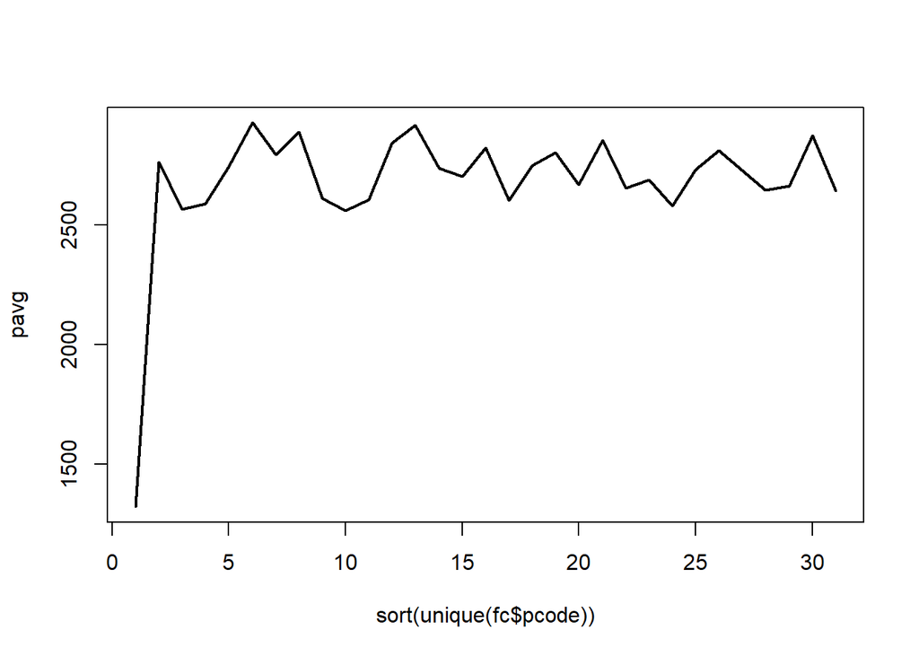

```r
# let's check the time-trend in the data that we analysed
pavg <- NULL
for(p in sort(unique(fc$pcode))) {pavg[p] <- sum(fc$y[fc$pcode==p])}
plot(sort(unique(fc$pcode)), pavg,type='l',lwd=2)
```

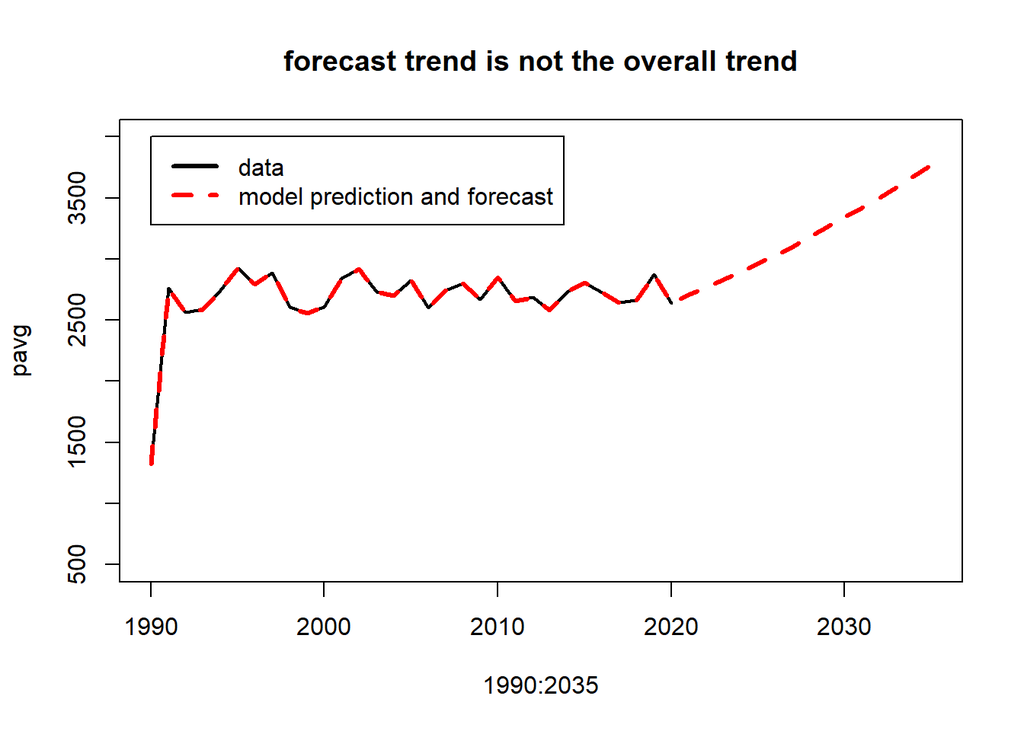

```r
# now let's extrapolate forward by 15 years
# we will make a dataset with the older timerange plus data for the next 15 years
a <- 0:85
p <- 1990:2035
fc.fut10 <- data.frame(expand.grid(a,p))
names(fc.fut10) <- c('a','p')
fc.fut10$c <- fc.fut10$p - fc.fut10$a
fc.fut10$pcode <- fc.fut10$p-1989
fc.fut10$a <- factor(fc.fut10$a)
fc.fut10$p <- factor(fc.fut10$p)
fc.fut10$c <- factor(fc.fut10$c)
dv <- dummyVars(pcode ~ a + p + c,
              data=fc.fut10)
fc.fut10 <- cbind(fc.fut10,predict(dv, newdata = fc.fut10))
# add together with the

# now let's predict for this dataset
fc.fut10$ypred <- predict(fit.fc,newdata=fc.fut10, type='response')

# now let's plot these predictions
pavg.pred <- NULL
for(p in sort(unique(fc.fut10$pcode))) {pavg.pred[p] <- sum(fc.fut10$ypred[fc.fut10$pcode==p])}
pavg <- c(pavg.pred[1:31],rep(NA,15))
pavg.fut <- c(rep(NA,30),pavg.pred[31:46])
plot(1990:2035, pavg, type='l',lwd=2, ylim=c(500,4000),main='forecast trend is not the overall trend')
lines(1990:2035, pavg.pred, lty=2,lwd=3,col='red')
legend(1990,4000,legend=c('data','model prediction and forecast'),lty=c(1,2,2),col=c('black','red'),lwd=3)
```

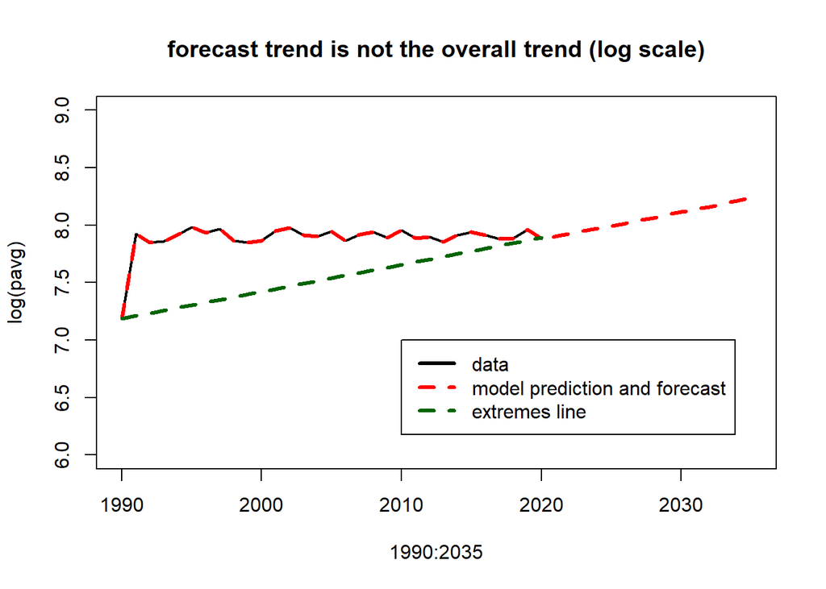

```r
# Let's put this on the scale of the linear predictor
plot(1990:2035, log(pavg), type='l',lwd=2, ylim=c(6,9),main='forecast trend is not the overall trend (log scale)')
lines(1990:2035, log(pavg.pred), lty=2,lwd=3,col='red')
segments(x0 = 1990, y0 = log(pavg.pred[1]), x1 = 2020, y1 = log(pavg.pred[20]), col = "darkgreen", lty=2, lwd=3)
legend(2010,7,legend=c('data','model prediction and forecast','extremes line'),lty=c(1,2,2),col=c('black','red','darkgreen'),lwd=3)
```

As you can see, even though the ‘trend’ has been virtually stable throughout the period, the model will predict an increase in the outcome because, if you draw a line between the first period (1990) and the last (2020), that line will have a very positive slope. Of course, this dataset is carefully constructed to show this phenomenon. What I intend to demonstrate, however, is that even if we selected a more ‘reasonable’ data range, it will still not be the case that the trend is an ‘average trend’ (or the maximum likelihood equivalent of a ‘least squares’ line) over the time period. It really is a virtually linear trend between the two constrained periods (see the example on the log scale), in this case the first and last period. This is very problematic if the constrained periods, due to random variation, deviate strongly from the overall ‘trend’ in the time-window of interest. Normally, in statistics, we minimize the influence of random fluctuation by using a statistical approach that takes all the data into account (this is a statistical principle known as ‘sufficiency’). However, with these constraints, as demonstrated, we do not properly take all the data into account to determine the trend. Since we are not extracting the ‘overall trend’, this demonstrates that we are extrapolating an arbitrary trend into the future. Do we really believe that this trend, between two arbitrarily chosen points in time, is the one that will continue into the future?

Note furthermore that in this example, the cohort trend is set to 0. But in normal cases, there will also be a cohort trend, and so cohort references will also matter. Variance on the cohort component, and its contribution to the drift parameter, is an important part of the next section.

Interesting sidenote: when we predicted ‘future’ data, the model can of course use the age coefficients since the future age-range is identical to the current one. It can also use a large portion of the cohort coefficients, since many of them are still alive in the future. However, some cohort coefficients (the oldest) are not used, since those cohorts have aged out of the data. Furthermore, for the youngest cohorts in the data, the model does not have coefficients; instead, for these cohorts the model automatically treats them as it treats the reference cohort. Since the youngest cohort is a reference cohort in the ‘extremes’ constraints of Nordpred, this requires no further work. But if you have set (e.g.) the two middle cohorts to be equal, you need to do some more work to make sure the prediction will use the coefficients of the youngest cohort in your data. Note that, either way (‘extremes’ or not), this is still a patchwork solution: in some cases, one may want to choose to look for some pattern in the cohort effects and extrapolate those, just like how we extrapolate the drift parameter. However, the patchwork solution is usually not a problem because most cancers have very low incidence at the youngest ages.

The solution

Nordpred solves this issue by checking a model for the entire time series with a model for only the last two datapoints. However, this compares models to the same data that they are also fitted on. Hence, I believe a better solution can be found.

We do statistics for roughly 3 different reasons; description (exploration), prediction, and explanation (causal inference). Our aim informs the methodology that we should employ. From a causal perspective, we can never know the constraints that lead to the ‘true’ APC decomposition. We have to use external information to make these decisions; though, arguably choosing the most extreme periods or cohorts to be equal is unlikely to correspond to reality (adjacent cohorts are more likely to be similar and therefore equal). However, for the purposes of prediction, techniques such as cross-validation have been developed to determine optimal constraints. Unfortunately, forecasting is a bit different from a normal prediction task, because you cannot randomly select some datapoints to serve as a training set and some datapoints to serve as a validation set. Since our task is to predict the future, instead we can use a ‘leave-future-out’ set. This set will be used to find the model that best forecasts the trend in some time period, and we will subsequently extrapolate that trend to the real unknown future.

We could do this in a number of ways. There are a number of different approaches to ‘solving’ the linear identification problem. For example, using tight Bayesian priors on the period and cohort dimensions could work; trying different prior specifications and finding out which is the best one might be fruitful.

For now, we’ll stay closer to home; we will vary the different types of constraints that can be imposed on an APCMC model. We will check not just the fit of a model with the ‘extremes’ constraints, but also of a model that sets e.g. the two middle cohorts to be equal, or the middle and the final cohort, and so forth. Using fit criteria such as root mean squared error (RMSE) or mean absolute error (MAE) we will then select the best model. The only tricky bit is to determine which period of data to take as the ‘future’ to leave out. Let’s take the final 33%; the period 2010 to 2020.

```r
fc <- f
# get rid of columns we don't need for this package
fc$aff <- fc$peff <- fc$ceff <- fc$lnpop <- fc$c <- NULL
# and rename age, period, and y
names(fc) <- c("Age","Period","cases")
# make an lnpop of 0 since we assume population stays constant and ln(1)=0
fc$PY <- 1

# split into training and validation data
fc.tr <- fc[fc$Period <= 2009,]
fc.val <- fc[fc$Period > 2009,]

# check this data
sort(unique(fc.tr$Period))
```

```
##  [1] 1990 1991 1992 1993 1994 1995 1996 1997 1998 1999 2000 2001 2002 2003 2004
## [16] 2005 2006 2007 2008 2009
```

```r
sort(unique(fc.tr$Age))
```

```
##  [1]  0  1  2  3  4  5  6  7  8  9 10 11 12 13 14 15 16 17 18 19 20 21 22 23 24
## [26] 25 26 27 28 29 30 31 32 33 34 35 36 37 38 39 40 41 42 43 44 45 46 47 48 49
## [51] 50 51 52 53 54 55 56 57 58 59 60 61 62 63 64 65 66 67 68 69 70 71 72 73 74
## [76] 75 76 77 78 79 80 81 82 83 84 85
```

```r
fc.tr$cases[fc.tr$Age==0]
```

```
##  [1] 0 0 0 0 0 0 0 0 0 0 0 0 0 0 0 0 0 0 0 0
```

```r
fc.tr$cases[fc.tr$Age==3]
```

```
##  [1] 0 0 0 0 0 2 0 1 0 0 0 0 0 0 0 0 0 0 1 1
```

```r
fc.tr$cases[fc.tr$Age==5]
```

```
##  [1] 0 0 1 0 3 1 3 1 1 0 1 0 1 2 1 1 1 1 0 1
```

```r
# we like to start modelling when there are not too many structural 0s (see problem #5 of APCMC models)

# to do this, I will use the multiAPCMC package, that was developed exactly for this purpose
source('R/getmode.R')
source('R/multiAPCMC.multifit.R')
source('R/multiAPCMC.reclist.R')
source('R/multiAPCMC.datashape.R')
source('R/multiAPCMC.singlefit.R')
source('R/multiAPCMC.multipred.R')
source('R/multiAPCMC.singlepred.R')
source('R/multiAPCMC.multipredtest.R')
source('R/multiAPCMC.ranktable.R')
source('R/multiAPCMC.retrievemodel.R')
source('R/multiAPCMC.randpred.R')
source('R/multiAPCMC.predsummary.R')

# let's set some parameters to check:
# which link functions to use (power5 or log)
# which data best predicts the future timetrend (vec.noperiod)
# which period references to try (vec.refper)
# which cohort references to try (vec.refcoh)

vec.link <- c('power5','log')
vec.noperiod <- c(5,10,15,20)
vec.refper <- c('extremes','outer','center', 'first middle','middle last',
                'first second', 'penultimate last')
vec.refcoh <- c('extremes','outer','center', 'first middle','middle last',
                'first second', 'penultimate last')

# fit 392 models to see which fits best:
fitlist <- multiAPCMC.multifit(data=fc.tr,
                               startestage=5,
                               vec.link=vec.link,
                               vec.noperiod=vec.noperiod,
                               vec.refper=vec.refper,
                               vec.refcoh=vec.refcoh,
                               nomodelmax=1024)
```

```
## [1] "fitting 392 APCMC models"
```

```r
# make predictions with these fitted models on the validation dataset:
predlist <- multiAPCMC.multipred(multiAPCMC.multifit.object=fitlist,
                                 futuredata=fc.val,
                                 cuttrend=rep(0,15))
```

```
## [1] "Projecting 11 periods into the future"
```

```r
# and then make a table, ranking these models using root mean squared error (RMSE)
ranktable <- multiAPCMC.ranktable(multiAPCMC.multifit.object=fitlist,
                                     multiAPCMC.multipred.object=predlist,
                                     rankhow='RMSE',
                                     oos.data=fc.val,
                                     validate.what='oos')

# let's check the top 10 models:
ranktable[1:10,]
```

```
##       link noperiod  ref_period   ref_cohort refper1st refper2nd refcoh1st
## 71  power5       20       outer        outer      1994      2005      1925
## 239 power5       20       outer  middle last      1994      2005      1954
## 15  power5       20       outer     extremes      1994      2005      1905
## 183 power5       20       outer first middle      1994      2005      1905
## 95  power5       20 middle last        outer      1999      2009      1925
## 263 power5       20 middle last  middle last      1999      2009      1954
## 39  power5       20 middle last     extremes      1999      2009      1905
## 207 power5       20 middle last first middle      1999      2009      1905
## 127 power5       20       outer       center      1994      2005      1954
## 151 power5       20 middle last       center      1999      2009      1954
##     refcoh2nd   is.AIC oos.RMSE  oos.MAE     driftSE is.pcAIC
## 71       1984 13844.98 12.57974 9.223229 0.001142706 692.2492
## 239      2004 13844.98 12.57980 9.223992 0.004271280 692.2492
## 15       2004 13844.98 12.57992 9.225220 0.002537799 692.2492
## 183      1954 13844.98 12.58009 9.227689 0.002344033 692.2492
## 95       1984 13844.98 12.59682 9.245494 0.001249144 692.2492
## 263      2004 13844.98 12.59689 9.246295 0.004265942 692.2492
## 39       2004 13844.98 12.59703 9.247807 0.002561126 692.2492
## 207      1954 13844.98 12.59722 9.250581 0.002404437 692.2492
## 127      1955 13844.98 12.65376 9.458980 0.021338146 692.2492
## 151      1955 13844.98 12.67336 9.485580 0.021344868 692.2492
```

```r
# and the worst 10 models:
ranktable[(dim(ranktable)[1]-9):(dim(ranktable)[1]),]
```

```
##     link noperiod       ref_period       ref_cohort refper1st refper2nd
## 364  log       10     first middle penultimate last      2000      2004
## 356  log       10           center penultimate last      2004      2005
## 380  log       10     first second penultimate last      2000      2001
## 378  log        5     first second penultimate last      2005      2006
## 386  log        5 penultimate last penultimate last      2008      2009
## 370  log        5      middle last penultimate last      2007      2009
## 338  log        5         extremes penultimate last      2005      2009
## 362  log        5     first middle penultimate last      2005      2007
## 354  log        5           center penultimate last      2007      2008
## 346  log        5            outer penultimate last      2006      2008
##     refcoh1st refcoh2nd   is.AIC     oos.RMSE      oos.MAE  driftSE is.pcAIC
## 364      2003      2004 6881.032 1.846365e+63 6.003072e+61 328.9814 688.1032
## 356      2003      2004 6881.032 2.609811e+63 8.485256e+61 328.9812 688.1032
## 380      2003      2004 6881.032 4.424787e+63 1.438627e+62 328.9813 688.1032
## 378      2003      2004 3310.281 5.696709e+67 1.852162e+66 541.4087 662.0561
## 386      2003      2004 3310.281 7.458446e+67 2.424953e+66 541.4091 662.0561
## 370      2003      2004 3310.281 1.112841e+68 3.618162e+66 541.4092 662.0561
## 338      2003      2004 3310.281 1.155101e+68 3.755561e+66 541.4088 662.0561
## 362      2003      2004 3310.281 1.198936e+68 3.898081e+66 541.4087 662.0561
## 354      2003      2004 3310.281 1.660460e+68 5.398628e+66 541.4092 662.0561
## 346      2003      2004 3310.281 2.046870e+68 6.654957e+66 541.4089 662.0561
```

```r
# what is the rank of the model with extremes for both period and cohort?
# i.e. the 'Nordpred' model? (of course, I should add that this is an extreme toy example)

# the first 'Nordpred' model has rank 31, it uses 15 years of data. It doesn't do so bad!
ranktable[31,]
```

```
##     link noperiod ref_period ref_cohort refper1st refper2nd refcoh1st refcoh2nd
## 5 power5       15   extremes   extremes      1995      2009      1910      2004
##     is.AIC oos.RMSE  oos.MAE     driftSE is.pcAIC
## 5 10464.95 12.94399 9.337043 0.002452321 697.6635
```

```r
# what about the 'Nordpred' models with 20 years of data?
ranktable[ranktable$noperiod==20 & ranktable$ref_period=='extremes' & ranktable$ref_cohort=='extremes',]
```

```
##     link noperiod ref_period ref_cohort refper1st refper2nd refcoh1st refcoh2nd
## 7 power5       20   extremes   extremes      1990      2009      1905      2004
## 8    log       20   extremes   extremes      1990      2009      1905      2004
##     is.AIC oos.RMSE  oos.MAE     driftSE is.pcAIC
## 7 13844.98 15.59873 11.50997 0.002382277 692.2492
## 8 13826.31 16.60977 12.18574 0.010981385 691.3156
```

The table of best models shows that we should use the full range of data, but we should not use the ‘extremes’ constraint for period (maybe for cohort this is OK; see the 3rd best model). The best model has the ‘outer’ constraints for both period and cohort; those represent the 20% and 80% quantiles of the period and cohort range.

The RMSE of these models is around 12.6, and the MAE is around 9.2. The best ‘Nordpred’ model uses 15 years of data and has an RMSE of 12.9 and 9.3. This is not bad, but clearly we could do better.

The RMSE of the ‘Nordpred’ models that used all 20 years of data, however, is quite a lot worse: their RMSE is 15.6 and 16.6, and MAEs of 11.5 and 12.19, for power5 and log links, respectively.

So how well does our new model predict the future?

To determine this, we will use the characteristics of the best model, fit it to the full total data, and then predict the unknown future:

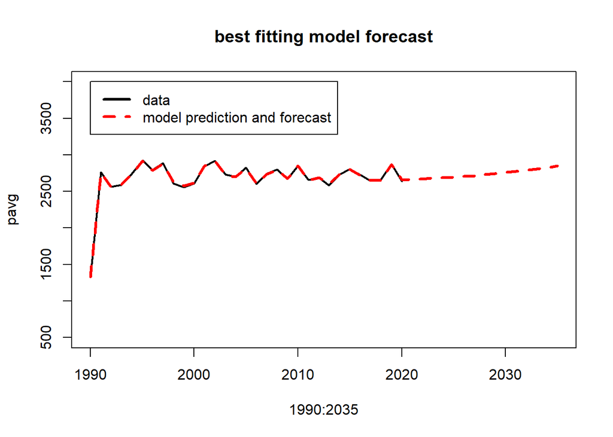

```r
perlength <- length(unique(fc$Period)) - length(unique(fc.tr$Period))
rank1ds <- multiAPCMC.datashape(fc,
                                  noperiod=ranktable$noperiod[1]+perlength,
                                  startestage=5,
                                  refper1st=ranktable$refper1st[1],
                                  refper2nd=ranktable$refper2nd[1],
                                  refcoh1st=ranktable$refcoh1st[1],
                                  refcoh2nd=ranktable$refcoh2nd[1])
fitbest <- multiAPCMC.singlefit(rank1ds,link=ranktable$link[1])

# now let's use this model on a future dataset
a <- 0:85
p <- 2021:2035
fc.fut10 <- data.frame(expand.grid(a,p))
names(fc.fut10) <- c('Age','Period')
fc.fut10$PY <- 1
years <- 1990:2035

predsingle <- multiAPCMC.singlepred(multiAPCMC.singlefit.object=fitbest,
                    futuredata=fc.fut10,
                    noproj=length(p),
                    cuttrend=rep(0,15))
plot(1990:2035, pavg, type='l',lwd=2, ylim=c(500,4000),main='best fitting model forecast')
incyear.pred <- multiAPCMC.predsummary(years,predsingle)
lines(years,incyear.pred$pred, col='red', lty=2,lwd=3)
legend(1990,4000,legend=c('data','model prediction and forecast'),lty=c(1,2,2),col=c('black','red'),lwd=3)
```

This looks a lot better!

But we can make it look even better by adding the confidence density:

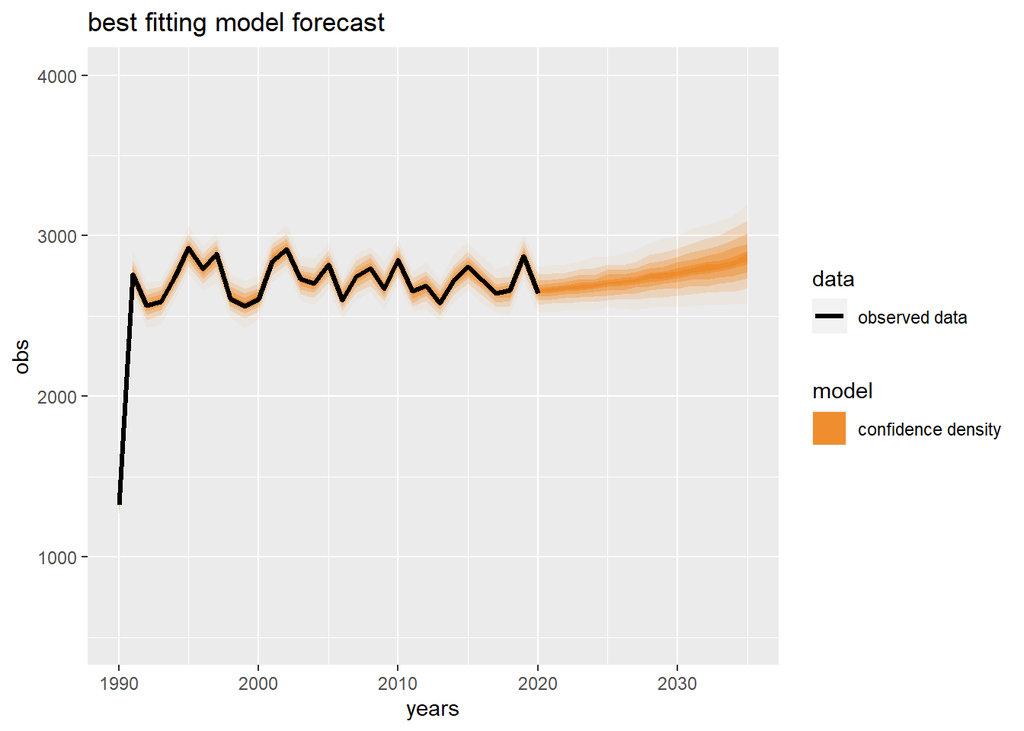

2. Extreme cohort constraints result in higher estimator variance than necessary.

The problem

In the previous example I demonstrated that the period component of drift, when using extreme constraints, is determined by drawing a line between the two extreme periods. To determine the entire drift, what is also done, is drawing a similar line between the two extreme cohorts, and then calculating an average between those two lines.

Usually, datasets are constructed by selecting an age range (e.g. 0 to 85) in a particular time period (e.g. calendar years 1990 to 2010). This results in a ‘rectangular’ dataset. With rectangular, we are referring to its shape in a Lexis diagram. See below an example for the year 1990 to 2000, and ages 0 to 10. The blue diagonal starting in 1991 is the 1991 birth cohort. We have at least 8 datapoints on this cohort.

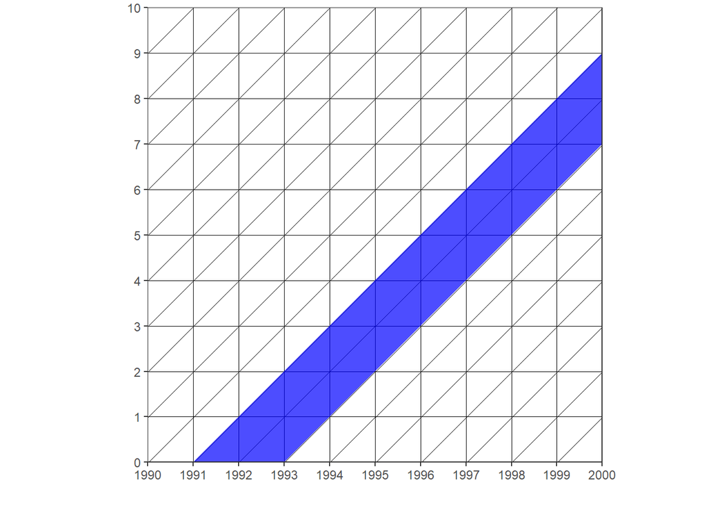

```r
library(LexisPlotR)
lex <- lexis_grid(year_start = 1990, year_end = 2000, age_start = 0, age_end = 10)
lex <- lexis_cohort(lg = lex, cohort = 1991, fill = 'blue')
lex <- lexis_cohort(lg = lex, cohort = 1992, fill = 'blue')
lex
```

But what about the ‘extreme’ cohorts?

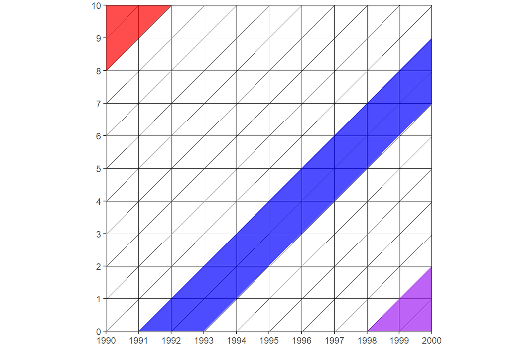

```r
lex <- lexis_grid(year_start = 1990, year_end = 2000, age_start = 0, age_end = 10)
lex <- lexis_cohort(lg = lex, cohort = 1991, fill = 'blue')
lex <- lexis_cohort(lg = lex, cohort = 1992, fill = 'blue')
lex <- lexis_cohort(lg = lex, cohort = 1980, fill = 'red')
lex <- lexis_cohort(lg = lex, cohort = 1981, fill = 'red')
lex <- lexis_cohort(lg = lex, cohort = 1999, fill = 'purple')
lex <- lexis_cohort(lg = lex, cohort = 1998, fill = 'purple')
lex
```

The extreme cohorts only contribute 1 ‘datapoint’ (age by year combination) of data. That means that, frequently, those cohorts will have strong fluctuations just due to low number of datapoints. Given that the drift parameter is partly determined by the line between these two cohorts, this affects not just the parameter estimates for these cohorts, but it affects the entire age-period-cohort decomposition.

This is compounded by the fact that extreme cohorts are also more likely to suffer from low number of cases. That is problem #5, which we will deal with later.

I will demonstrate the effect of this doing a simple simulation study. We will do the following: we will determine the data generating process (DGP) of some horizontal time trend, we will generate a simple dataset from this DGP, fit an APC model with ‘extreme’ constraints and an APC model with ‘outer’ constraints, save the drift estimates from this model, and then re-generate the dataset, save the drift estimates again, and so forth. Then we will visualize this.

```r
a <- 0:85
p <- 1990:2020
f <- data.frame(expand.grid(a,p))
names(f) <- c('Age','Period')
f$c <- f$Period - f$Age

table(f$c)
```

```
##
## 1905 1906 1907 1908 1909 1910 1911 1912 1913 1914 1915 1916 1917 1918 1919 1920
##    1    2    3    4    5    6    7    8    9   10   11   12   13   14   15   16
## 1921 1922 1923 1924 1925 1926 1927 1928 1929 1930 1931 1932 1933 1934 1935 1936
##   17   18   19   20   21   22   23   24   25   26   27   28   29   30   31   31
## 1937 1938 1939 1940 1941 1942 1943 1944 1945 1946 1947 1948 1949 1950 1951 1952
##   31   31   31   31   31   31   31   31   31   31   31   31   31   31   31   31
## 1953 1954 1955 1956 1957 1958 1959 1960 1961 1962 1963 1964 1965 1966 1967 1968
##   31   31   31   31   31   31   31   31   31   31   31   31   31   31   31   31
## 1969 1970 1971 1972 1973 1974 1975 1976 1977 1978 1979 1980 1981 1982 1983 1984
##   31   31   31   31   31   31   31   31   31   31   31   31   31   31   31   31
## 1985 1986 1987 1988 1989 1990 1991 1992 1993 1994 1995 1996 1997 1998 1999 2000
##   31   31   31   31   31   31   30   29   28   27   26   25   24   23   22   21
## 2001 2002 2003 2004 2005 2006 2007 2008 2009 2010 2011 2012 2013 2014 2015 2016
##   20   19   18   17   16   15   14   13   12   11   10    9    8    7    6    5
## 2017 2018 2019 2020
##    4    3    2    1
```

```r
# nicely demonstrates only 1 observation for the oldest and youngest cohorts
# note that 1935 and 1990 are the first cohorts with full observations (31)

# set age period and cohort effects
# (we will use a log-link now, but let's assume a constant offset: i.e. no offset)
set.seed(5)
peff <- rexp(31)
f$aff <- log(1 + f$Age*0.010 + f$Age^2*0.010 - f$Age^3*0.00010+0.001)
# I give a fairly strong start to age so that the effect of structural 0s is removed
f$peff <- log(rep(peff,each=length(a)))
f$ceff <- runif(length(f$aff))
# add them together with random error to produce y:
f$PY <- 1
f$cases <- rpois(length(f$aff),exp((f$aff + f$peff + f$ceff)))
fc <- f
fc$c <- fc$aff <- fc$peff <- fc$ceff <- NULL

# estimate extremes model
dat.ext <- multiAPCMC.datashape(fc,
                                  noperiod=31,
                                  startestage=0,
                                  refper1st=1990,
                                  refper2nd=2020,
                                  refcoh1st=1905,
                                  refcoh2nd=2015)
fit.ext <- multiAPCMC.singlefit(dat.ext,link='power5')

# estimate outer model with full observations
dat.out <- multiAPCMC.datashape(fc,
                                  noperiod=31,
                                  startestage=0,
                                  refper1st=1990,
                                  refper2nd=2020,
                                  refcoh1st=1935,
                                  refcoh2nd=1985)
fit.out <- multiAPCMC.singlefit(dat.out,link='power5')

# make predictions
bs.ext <- multiAPCMC.predsummary(years,multiAPCMC.singlepred(multiAPCMC.singlefit.object=fit.ext,
                    futuredata=fc.fut10,
                    noproj=15,
                    cuttrend=rep(0,15)),
                                  poissondraw=FALSE)

bs.out <- multiAPCMC.predsummary(years,multiAPCMC.singlepred(multiAPCMC.singlefit.object=fit.out,
                    futuredata=fc.fut10,
                    noproj=15,
                    cuttrend=rep(0,15)),
                                  poissondraw=FALSE)

# now let's do this many times
# each time a new draw from the same DGP and estimating our models
simsize <- 499
drift.ext <- drift.out <- rep(NA,simsize)
suppressWarnings({
set.seed(1)
for(b in 1:simsize) {
  # draw from DGP
  f$cases <- rpois(length(f$aff),exp((f$aff + f$peff + f$ceff)))
  fc <- f
  fc$c <- fc$aff <- fc$peff <- fc$ceff <- NULL

  # re-estimate extremes model
  dat.ext <- multiAPCMC.datashape(fc,
                                  noperiod=31,
                                  startestage=0,
                                  refper1st=1990,
                                  refper2nd=2020,
                                  refcoh1st=1905,
                                  refcoh2nd=2015)
  fit.ext <- multiAPCMC.singlefit(dat.ext,link='power5')
  drift.ext[b] <- fit.ext$glm$coefficients['pcode']

  # re-estimate outer model with full observations
  dat.out <- multiAPCMC.datashape(fc,
                                  noperiod=31,
                                  startestage=0,
                                  refper1st=1990,
                                  refper2nd=2020,
                                  refcoh1st=1935,
                                  refcoh2nd=1985)
  fit.out <- multiAPCMC.singlefit(dat.out,link='power5')
  drift.out[b] <- fit.out$glm$coefficients['pcode']
}
})
sd(drift.ext)
```

```
## [1] 0.001040598
```

```r
sd(drift.out)
```

```
## [1] 0.0007084225
```

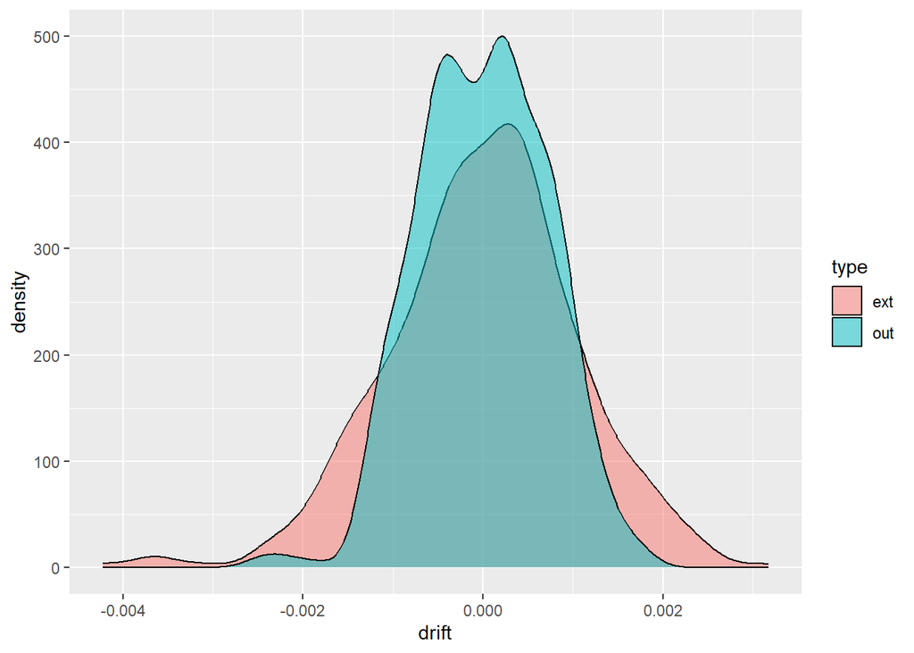

```r
# ext has a bigger variance, as explained

drift.dat <- data.frame(drift=c(drift.ext-mean(drift.ext),drift.out-mean(drift.out)),
                        type=rep(c('ext','out'),each=simsize))

ggplot(drift.dat, aes(drift, fill = type)) + geom_density(alpha = 0.5)
```

As can be seen, the version with ‘extreme’ constraints has a bigger spread.

The solution

One solution has already been shown; namely, not to use ‘extreme’ constraints but instead ‘outer’ constraints or other constraints on cohort that make use of more observations.

There are two alternative solutions. One solution is to use a regularization technique, such as a penalty parameter like in a LASSO (least absolute shrinkage and selection operator) which limits the values that the drift parameter can take and especially prevents it from taking large values. A solution of a similar nature is to use tight Bayesian priors on the drift component. We will explore this idea further as a solution to problem #4. Hence, this solution might actually water two plants with one hose. Perhaps even three plants, because Bayesian penalty parameters or Bayesian constraints can also be used as a ‘solution’ to the linear dependency problem. That could help entirely avoid relying on extreme constraints.

That brings me to another solution. An alternative to the ‘extremes’ constraint is to use the Holford parameterization. In this approach, a design matrix is constructed so that non-linear period and non-linear cohort effects are orthogonal to the linear drift component. By doing this, drift is not determined using ‘extreme’ constraints; it uses all the data. This offers us an elegant mathematical solution. However, it is in no way guaranteed to result in a meaningful causal interpretation, and it also does not necessarily result in the best predictive model either. This is [a common problem](https://link.springer.com/article/10.1007/s13524-013-0251-z) with the various APC constraints out there: they offer various mathematical solutions, but mathematics without a conceptual basis does not produce information. At best, we could incorporate the Holford solution into the APCMC package, to compare its predictions with all the other possible constraints; perhaps, in some cases, it will capture the trend that we wish to carry onwards into the future.

3. Variance of the outcome variable is not correctly estimated

The problem

Incidence is a count variable, which are canonically expected to follow a Poisson distribution. Hence, many APC models for incidence indeed are Poisson GLMs. However, Poisson distributed variables have a variance that is equal to their mean, i.e. Var(Y|X) = E[Y|X]. This is problematic, because in practice we can observe variances that are greater than the mean of the variable Y at X; a hint that, perhaps, some incidences do not follow a Poisson distribution. In practice, what we often see is that the variance is greater than the mean. This is known as overdispersion. This is a problem for forecasting future values, because when forecasting incidence we tend to show the prediction interval, rather than the confidence interval. The prediction interval uses both the standard error of the mean (which the confidence interval uses), plus the standard deviation of the outcome variables. Hence, we need a good estimate of the variance of the outcome variable.

We would like to base our estimate of the variance on the empirically observed variance. Hence, we need to allow the variance estimate to decouple, in some way, from the estimate of the mean. An alternative to the Poisson distribution in the presence of overdispersion, is the negative binomial model, which can also be written as a [Gamma-Poisson mixture model](https://timothy-barry.github.io/posts/2020-06-16-gamma-poisson-nb/). Essentially, using such a model, we can write our variance as $E[Y|X] + \frac{E[Y|X]^{2}}{\phi}$. In other words, we tag the $\frac{E[Y|X]^{2}}{\phi}$ term onto the original variance estimate. The $\phi$ parameter allows us to rescale this term: if it goes to infinity, then we approach the ordinary Poisson variance. In other words, it can deal with overdispersion. However, it does still assume that variance is a function of the mean; just rescaled. This can be empirically investigated, and an even more flexible distribution chosen if empirical reality does not match our modelling assumptions.

In order to allow the phi parameter to adequately rescale the variance so that it matches empirical variance, we also have to let the model know what parts of our empirical observations are structural, and what parts are stochastic. What do I mean by that? What is considered structural or stochastic depends on our modelling aims. To be brief, in the case of forecasting, structural parameters are parameters that we choose to use in our forecast in a deterministic fashion. For example, we model an age curve because we believe that the age distribution of cancer (conditional on period and cohort) will remain about the same in the future. Non-linear cohort, too, is expected to carry some information about future incidence of cancer; cohorts that have higher relative rates of cancer now, are expected to also have higher relative rates of cancer in the future (conditional on age and period). Finally, the drift component is also believed to carry some information that we dare to extrapolate into the future; steady improvements in cancer detection technology, worse health behaviour, and so forth. Hence, we extrapolate the drift to forecast future cancer.

On the other hands, stochastic components are fluctuations in cancer incidence that are considered to be ‘random’; these are forces that we believe that we cannot predict in advance. It doesn’t mean that they are necessarily unexplained; it is very well possible that we can explain why these fluctuations happened. However, explanations ‘after the fact’ are not very useful when forecasting.

Importantly, any components that are modelled as structural, will not be counted as stochastic.

So what about non-linear period effects? In APCMC models, we include terms for non-linear period effects, i.e. we treat them as structural. This is strange, because we do not use information on non-linear period effects when we extrapolate towards the future. Generally, this is the case because there is no clear pattern in the non-linear period effects. How do you extrapolate such a thing? For example, if there were a cosine pattern, you could extrapolate that. But if the pattern appears random (hint: because it is random, i.e. stochastic), there is no way to extrapolate it. This also shows itself when we do in fact extrapolate from an APCMC model; frequently, the prediction interval in the first few years of forecast will be much smaller than the range observed in empirically observed time series (even in the absence of overdispersion). The solution is simple: not to model non-linear period effects as structural, so that these fluctuations can be counted towards the variance instead.

Let’s demonstrate this now:

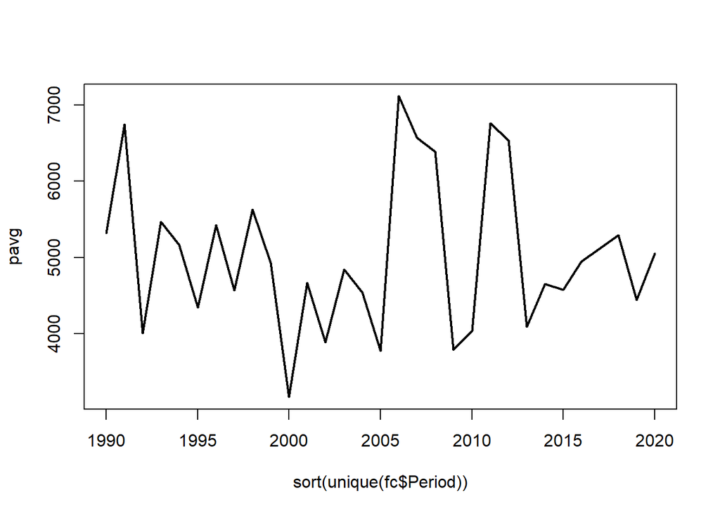

```r
# let's make a time series with some fluctuation
set.seed(12) # 12
a <- 0:85
p <- 1990:2020
f <- data.frame(expand.grid(a,p))
names(f) <- c('a','p')
f$c <- f$p - f$a
# set age period and cohort effects
# (we will use a log-link now, but let's assume a constant offset: i.e. no offset)
peff <- rnorm(31,0.5,0.5) # 0.01 witg #12
peff <- ifelse(peff < 0,0,peff)
f$aff <- log(f$a*0.010 + f$a^2*0.010 - f$a^3*0.00010+0.001)
f$peff <- log(rep(peff,each=length(a)))
f$ceff <- runif(length(f$aff))
# add them together with random error to produce y:
f$y <- rnegbin(length(f$aff),50+exp(f$aff + f$peff + f$ceff),theta=0.5)
fc <- f

# get rid of columns we don't need for this package
fc$aff <- fc$peff <- fc$ceff <- fc$lnpop <- fc$c <- NULL
# and rename age, period, and y
names(fc) <- c("Age","Period","cases")
# make an lnpop of 0 since we assume population stays constant and ln(1)=0
fc$PY <- 1

# let's check the time-trend in the data that we analysed
pavg <- NULL
for(p in sort(unique(fc$Period))) {pavg[p+1-min(fc$Period)] <- sum(fc$cases[fc$Period==p])}
plot(sort(unique(fc$Period)), pavg,type='l',lwd=2)
```

```r
# split into training and validation data
fc.tr <- fc[fc$Period <= 2009,]
fc.val <- fc[fc$Period > 2009,]

# check this data
sort(unique(fc.tr$Period))
```

```
##  [1] 1990 1991 1992 1993 1994 1995 1996 1997 1998 1999 2000 2001 2002 2003 2004
## [16] 2005 2006 2007 2008 2009
```

```r
sort(unique(fc.tr$Age))
```

```
##  [1]  0  1  2  3  4  5  6  7  8  9 10 11 12 13 14 15 16 17 18 19 20 21 22 23 24
## [26] 25 26 27 28 29 30 31 32 33 34 35 36 37 38 39 40 41 42 43 44 45 46 47 48 49
## [51] 50 51 52 53 54 55 56 57 58 59 60 61 62 63 64 65 66 67 68 69 70 71 72 73 74
## [76] 75 76 77 78 79 80 81 82 83 84 85
```

```r
fc.tr$cases[fc.tr$Age==0]
```

```
##  [1]   7   6  69  13  89  11 101 110 131  23  76   3   6   0   0 151 128   0   0
## [20]  98
```

```r
fc.tr$cases[fc.tr$Age==3]
```

```
##  [1] 228  59  18   0 204   0   6   1  26  17  17  29 174  94 301  78 513  21   1
## [20]  35
```

```r
fc.tr$cases[fc.tr$Age==5]
```

```
##  [1]  17 164  48  38   0 138   3  48 251  18   0  24 120  25  43 138 149  48  22
## [20]  77
```

```r
vec.link <- c('log')
vec.noperiod <- c(20)
vec.refper <- c('extremes','outer')
vec.refcoh <- c('extremes','outer')
startestage <- 10

# fit 392 models to see which fits best:
fitlist <- multiAPCMC.multifit(data=fc.tr,
                               startestage=startestage,
                               vec.link=vec.link,
                               vec.noperiod=vec.noperiod,
                               vec.refper=vec.refper,
                               vec.refcoh=vec.refcoh,
                               nomodelmax=1024)
```

```
## [1] "fitting 4 APCMC models"
```

```r
# make predictions with these fitted models on the validation dataset:
predlist <- multiAPCMC.multipred(multiAPCMC.multifit.object=fitlist,
                                 futuredata=fc.val,
                                 cuttrend=rep(0,15))
```

```
## [1] "Projecting 11 periods into the future"
```

```r
# and then make a table, ranking these models using root mean squared error (RMSE)
ranktable <- multiAPCMC.ranktable(multiAPCMC.multifit.object=fitlist,
                                     multiAPCMC.multipred.object=predlist,
                                     rankhow='RMSE',
                                     oos.data=fc.val,
                                     validate.what='oos')
ranktable
```

```
##   link noperiod ref_period ref_cohort refper1st refper2nd refcoh1st refcoh2nd
## 3  log       20   extremes      outer      1990      2009      1924      1980
## 1  log       20   extremes   extremes      1990      2009      1905      1999
## 4  log       20      outer      outer      1994      2005      1924      1980
## 2  log       20      outer   extremes      1994      2005      1905      1999
##     is.AIC oos.RMSE  oos.MAE     driftSE is.pcAIC
## 3 120729.2 86.22660 55.09900 0.001401599 6036.459
## 1 120729.2 86.23344 55.09251 0.002649702 6036.459
## 4 120729.2 86.82501 54.64498 0.002279368 6036.459
## 2 120729.2 86.83365 54.64272 0.003295964 6036.459
```

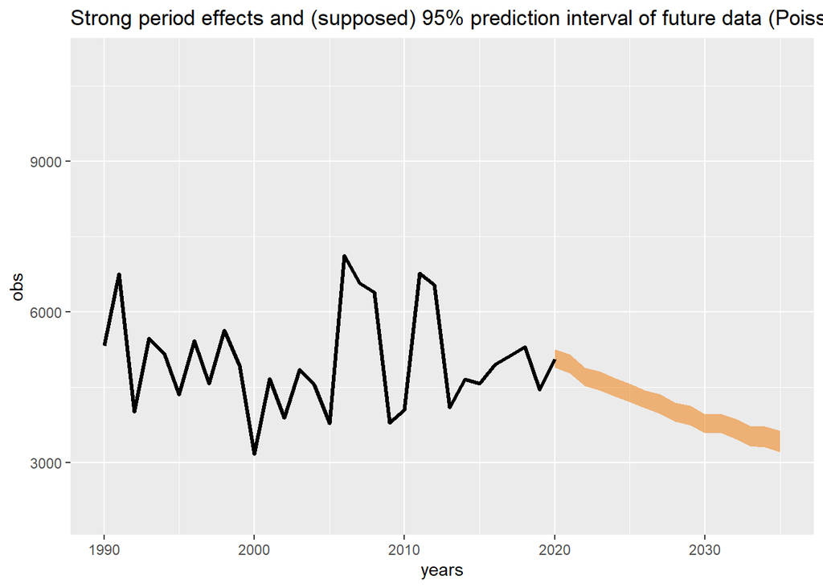

```r
perlength <- length(unique(fc$Period)) - length(unique(fc.tr$Period))
rank1ds <- multiAPCMC.datashape(fc,
                                  noperiod=ranktable$noperiod[1]+perlength,
                                  startestage=startestage,
                                  refper1st=ranktable$refper1st[1],
                                  refper2nd=ranktable$refper2nd[1],
                                  refcoh1st=ranktable$refcoh1st[1],
                                  refcoh2nd=ranktable$refcoh2nd[1])
fitbest <- multiAPCMC.singlefit(rank1ds,link=ranktable$link[1])
# let's also fit a negative binomial alternative already
fitbest.nb <- multiAPCMC.singlefit(rank1ds,family='negbin')
# and a negative binomial where non-linear period effects go to variance
fitbest.nb0 <- multiAPCMC.singlefit(rank1ds,family='negbin',pereff=0)

# now let's use this model on a future dataset
a <- 0:85
p <- 2021:2035
fc.fut10 <- data.frame(expand.grid(a,p))
names(fc.fut10) <- c('Age','Period')
fc.fut10$PY <- 1
years <- 1990:2035

# let's draw 499 many times and save the quantiles
bssize <- 999
bsdat <- multiAPCMC.predsummary(years,multiAPCMC.randpred(multiAPCMC.singlefit.object=fitbest,
                    futuredata=fc.fut10,
                    noproj=length(p),
                    cuttrend=rep(0,15)),
                                         poissondraw=TRUE)

bsdat.nb <- multiAPCMC.predsummary(years,multiAPCMC.randpred(multiAPCMC.singlefit.object=fitbest.nb,
                    futuredata=fc.fut10,
                    noproj=length(p),
                    cuttrend=rep(0,15)),
                                         poissondraw=TRUE)

bsdat.nb0 <- multiAPCMC.predsummary(years,multiAPCMC.randpred(multiAPCMC.singlefit.object=fitbest.nb0,
                    futuredata=fc.fut10,
                    noproj=length(p),
                    cuttrend=rep(0,15)),
                                         poissondraw=TRUE)

for(b in 1:bssize) {
  bsdat <- rbind(bsdat,multiAPCMC.predsummary(years,multiAPCMC.randpred(multiAPCMC.singlefit.object=fitbest,
                    futuredata=fc.fut10,
                    noproj=length(p),
                    cuttrend=rep(0,15)),
                                         poissondraw=TRUE))
  bsdat.nb <- rbind(bsdat.nb,multiAPCMC.predsummary(years,multiAPCMC.randpred(multiAPCMC.singlefit.object=fitbest.nb,
                    futuredata=fc.fut10,
                    noproj=length(p),
                    cuttrend=rep(0,15)),
                                         poissondraw=TRUE))

    bsdat.nb0 <- rbind(bsdat.nb0,multiAPCMC.predsummary(years,multiAPCMC.randpred(multiAPCMC.singlefit.object=fitbest.nb0,
                    futuredata=fc.fut10,
                    noproj=length(p),
                    cuttrend=rep(0,15)),
                                         poissondraw=TRUE))
}

# from this, let's store some quantiles (this can probably be done in a more efficient way!)
predtable <- multiAPCMC.predsummary(years,predsingle)
predtable$pred_025 <- NA
predtable$pred_975 <- NA
predtable$pred_025.nb <- NA
predtable$pred_975.nb <- NA
predtable$pred_025.nb0 <- NA
predtable$pred_975.nb0 <- NA


for(y in 2020:2035) {

  qs <- quantile(bsdat$pred[bsdat$years==y],probs=c(0.025,0.975))
  predtable$pred_025[predtable$years==y] <- qs[1]
  predtable$pred_975[predtable$years==y] <- qs[2]

    qs <- quantile(bsdat.nb$pred[bsdat.nb$years==y],probs=c(0.025,0.975))
  predtable$pred_025.nb[predtable$years==y] <- qs[1]
  predtable$pred_975.nb[predtable$years==y] <- qs[2]

      qs <- quantile(bsdat.nb0$pred[bsdat.nb0$years==y],probs=c(0.025,0.975))
  predtable$pred_025.nb0[predtable$years==y] <- qs[1]
  predtable$pred_975.nb0[predtable$years==y] <- qs[2]


}
predtable$obs <- c(pavg,rep(NA,15))

prea <- c(0.05,0.20,0.40,0.60,0.80,0.90)
a <- prea - c(0,prea[-length(prea)])*0.75
# the  0.75 is an inverse amplification value; lower it for stronger colors

# plot with confidence levels
p <- ggplot(predtable,aes(years))
p +
  geom_ribbon(aes(ymin=pred_025,ymax=pred_975, fill='confidence density'),alpha=0.5) +
  geom_line(aes(y=obs,colour='observed data', linetype='observed data'),linewidth=1.2) +
  ggtitle("Strong period effects and (supposed) 95% prediction interval of future data (Poisson glm)") +
  scale_color_manual(name = "data", values = c("observed data" = "black",
                                                   "unobserved future" = "black")) +
  scale_fill_manual(name='model', values = c("confidence density" = "darkorange2")) +
  scale_linetype_manual(name='data',values=c("observed data" = "solid",
                                             "unobserved future" = "dashed")) +
  theme(legend.position = "none") +
  ylim(2000,11000)
```

Given the volatility of this time series, the 95% prediction interval of this model is unlikely to actually cover the true future data with 95% probability (known as the ‘coverage probability’). Let’s first check what it would look like if we respect the true variance of the model, but we keep modelling period effects. We do this by selecting a Negative Binomial (gamma-poisson) model instead of a Poisson model.

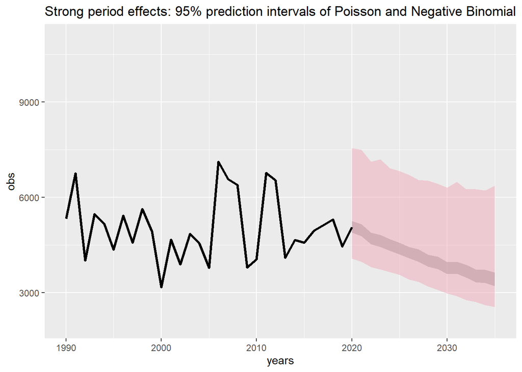

```r
# plot with confidence levels
p <- ggplot(predtable,aes(years))
p +
  geom_ribbon(aes(ymin=pred_025,ymax=pred_975, fill='confidence density poisson'),alpha=0.5) +
  geom_ribbon(aes(ymin=pred_025.nb,ymax=pred_975.nb, fill='confidence density negbin'), alpha=0.5) +

  geom_line(aes(y=obs,colour='observed data', linetype='observed data'),linewidth=1.2) +
  ggtitle("Strong period effects: 95% prediction intervals of Poisson and Negative Binomial") +
  scale_color_manual(name = "data", values = c("observed data" = "black",
                                                   "unobserved future" = "black")) +
  scale_fill_manual(name='model', values = c("confidence density poisson" = "darkorange2")) +
    scale_fill_manual(name='model', values = c("confidence density negbin" = "pink2")) +
  scale_linetype_manual(name='data',values=c("observed data" = "solid",
                                             "unobserved future" = "dashed")) +
  theme(legend.position = "none") +
  ylim(2000,11000)
```

The negative binomial confidence density has a pink color. The Poisson is still orange but because of opacity this is now a greyish pink. The point is: the negative binomial has a wider confidence interval. I think this new confidence interval does a far better job than the previous one. However, we are still modelling period effects as structural. Let’s stop doing that and see what happens.

The solution?

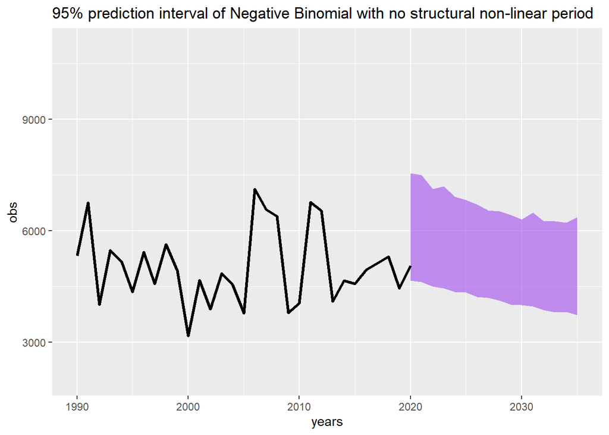

```r
p <- ggplot(predtable,aes(years))
p +
  geom_ribbon(aes(ymin=pred_025.nb0,ymax=pred_975.nb, fill='confidence density negbin no period'), alpha=0.5) +

  geom_line(aes(y=obs,colour='observed data', linetype='observed data'),linewidth=1.2) +
  ggtitle("95% prediction interval of Negative Binomial with no structural non-linear period") +
  scale_color_manual(name = "data", values = c("observed data" = "black",
                                                   "unobserved future" = "black")) +
  scale_fill_manual(name='model', values = c("confidence density negbin no period" = "purple2")) +
  scale_linetype_manual(name='data',values=c("observed data" = "solid",
                                             "unobserved future" = "dashed")) +
  theme(legend.position = "none") +
  ylim(2000,11000)
```

This looks worse to me. The reason is likely that the true data generating process (DGP) is period effects + a draw from a negative binomial distribution. If the actual DGP is Poisson + randomness in the period effects then I bet not modelling period effects would work better. Let’s have a look.

I will use the same code as above, but in the following code snippet, the line that generates f$y is changed:

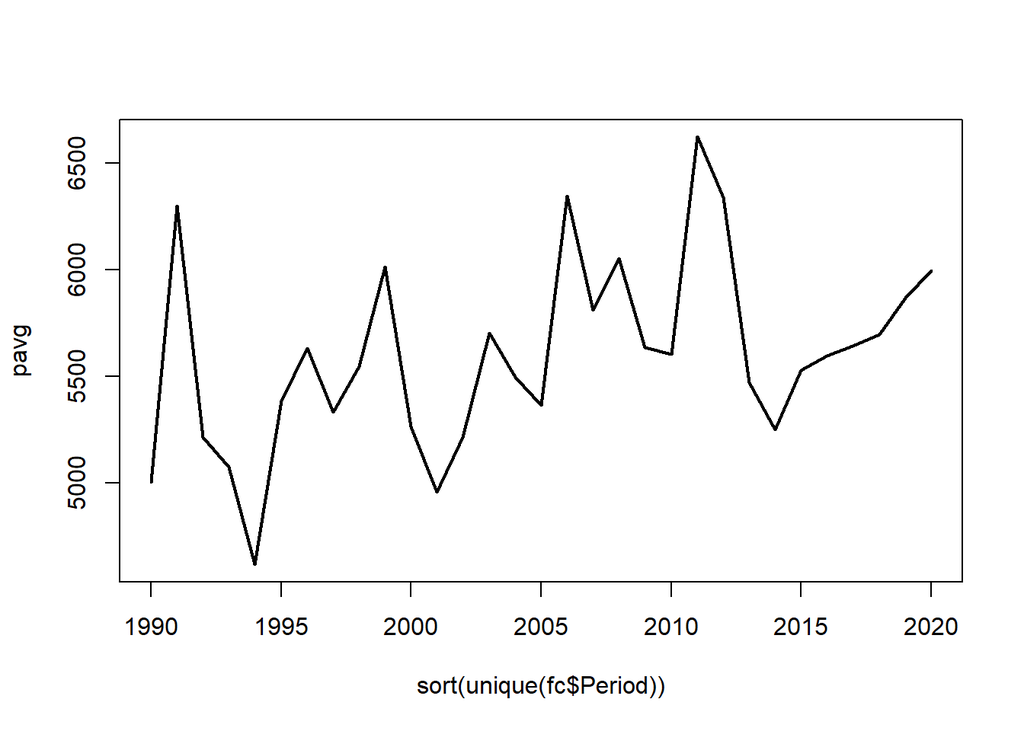

```
## [1] "fitting 4 APCMC models"
```

```
## [1] "Projecting 11 periods into the future"
```

```
##   link noperiod ref_period ref_cohort refper1st refper2nd refcoh1st refcoh2nd
## 3  log       20   extremes      outer      1990      2009      1924      1980
## 1  log       20   extremes   extremes      1990      2009      1905      1999
## 4  log       20      outer      outer      1994      2005      1924      1980
## 2  log       20      outer   extremes      1994      2005      1905      1999
##     is.AIC oos.RMSE   oos.MAE     driftSE is.pcAIC
## 3 11365.31 12.51193  9.756632 0.001319003 568.2657
## 1 11365.31 12.51805  9.767420 0.002309301 568.2657
## 4 11365.31 13.74903 10.838666 0.002072853 568.2657
## 2 11365.31 13.76802 10.866492 0.002899252 568.2657
```

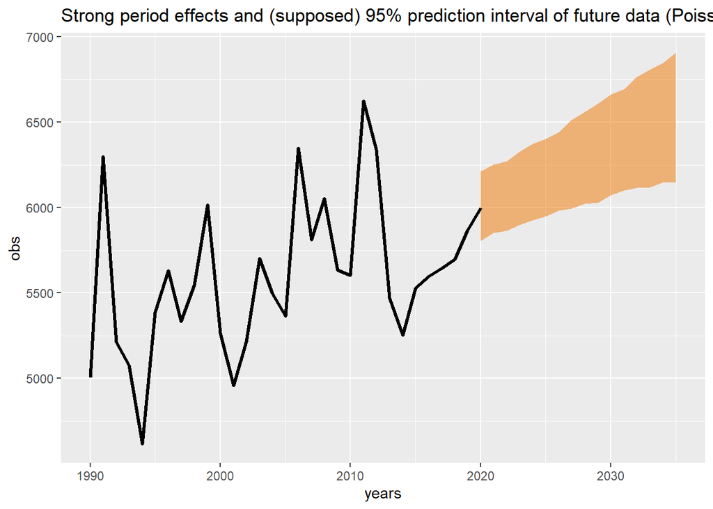

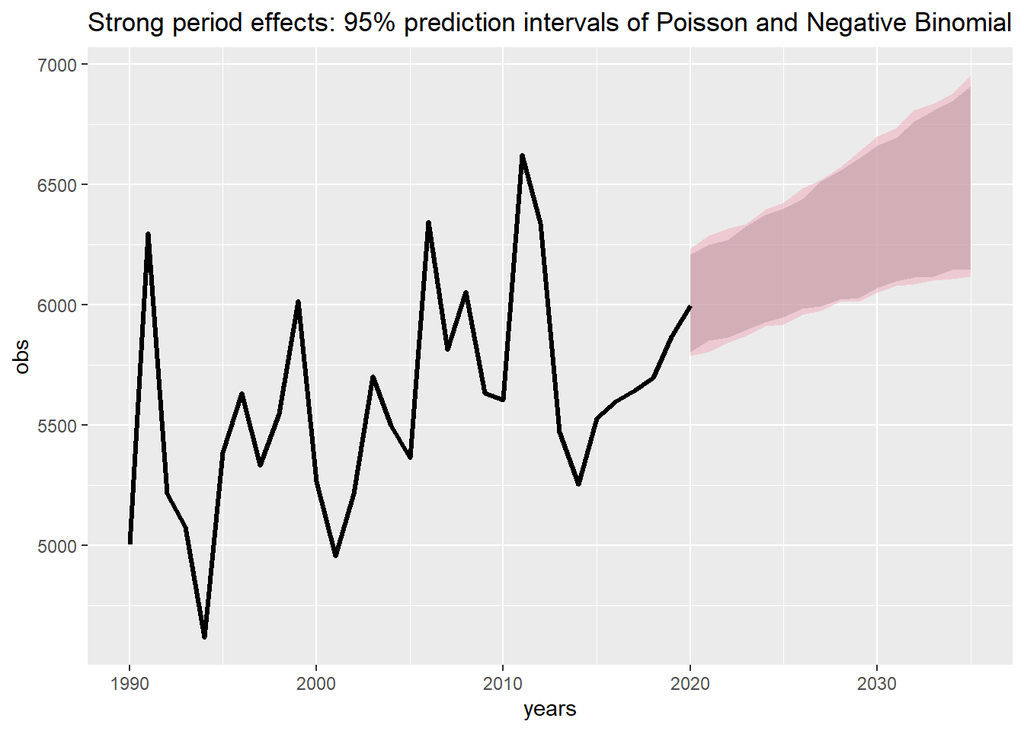

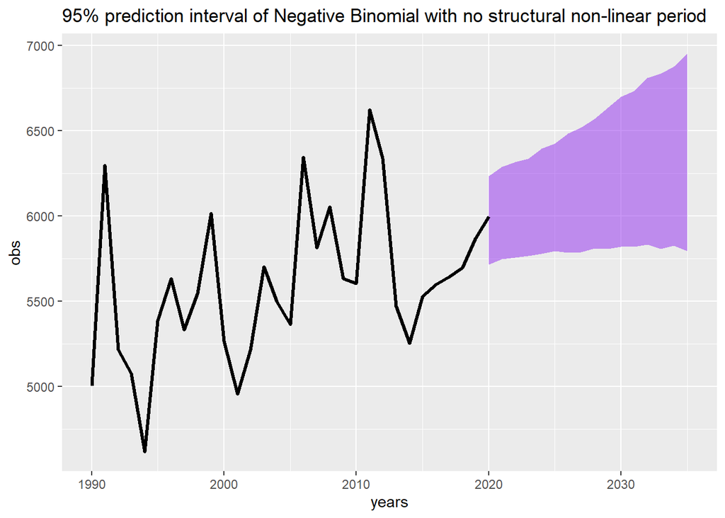

```r
# let's make a time series with some fluctuation
set.seed(12)
a <- 0:85
p <- 1990:2020
f <- data.frame(expand.grid(a,p))
names(f) <- c('a','p')
f$c <- f$p - f$a
# set age period and cohort effects
# (we will use a log-link now, but let's assume a constant offset: i.e. no offset)
peff <- rnorm(31,1,0.4)
peff <- ifelse(peff < 0,0,peff)
f$aff <- log(f$a*0.010 + f$a^2*0.010 - f$a^3*0.00010+0.001)
f$peff <- log(rep(peff,each=length(a)))
f$ceff <- runif(length(f$aff))
# add them together with random error to produce y:
f$y <- rpois(length(f$aff),50+exp(f$aff + f$peff + f$ceff))
fc <- f

# get rid of columns we don't need for this package
fc$aff <- fc$peff <- fc$ceff <- fc$lnpop <- fc$c <- NULL
# and rename age, period, and y
names(fc) <- c("Age","Period","cases")
# make an lnpop of 0 since we assume population stays constant and ln(1)=0
fc$PY <- 1

# let's check the time-trend in the data that we analysed
pavg <- NULL
for(p in sort(unique(fc$Period))) {pavg[p+1-min(fc$Period)] <- sum(fc$cases[fc$Period==p])}
plot(sort(unique(fc$Period)), pavg,type='l',lwd=2)
```

In this situation, where the true outcome distribution is Poisson, the negative binomial WITH non-linear period effects hardly does better than an ordinary Poisson model. In this instance, the negative binomial with non-linear period effects omitted performs much better.

I wouldn’t be entirely content with this, because here the size of this prediction interval is not big enough. The reason here is that our model does not perfectly approximate the DGP. However, not modelling non-linear period is clearly an improvement. And the nice thing about leave-future-out validation is that we can explore which model fits the DGP best. Hence, we don’t have to assume that the real model is negative binomial with (or without) non-linear period effects, or is Poisson with (or without) non-linear period effects and randomness on the period effect itself. We can simply test what works and then be clear about our underlying assumption.

Currently, choice of outcome distribution and with or without non-linear period effects are not yet part of the validation process (i.e. Ranktable). This would be possible, however. We would have to compare not just every observation in the validation set with the predicted mean, but every observation in the validation set with the predicted distribution. I might put this in the multiAPCMC package. For now, I recommend using multiAPCMC to determine the best mean model, and then visually comparing a Poisson with non-linear period effects modelled, to a negative binomial with non-linear period effects modelled, to a negative binomial without non-linear period effects modelled.

I should mention that other error structures should also be explored. A common error structure is Random Walk(1). In this structure, we see error as something that manifests relative to the previous data point, rather than relative to some underlying trend (though both are also possible). An APC model with this in mind can be found here.

Now, one more thing before I go to the next issue. I want to make absolutely clear that we could, if there is some sort of pattern, extrapolate some period structure. I’ll demonstrate the idea behind it, but will omit using actual APC software:

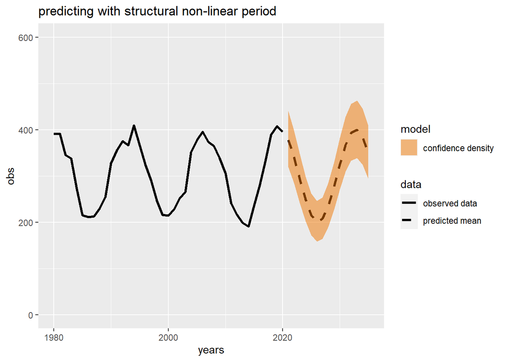

```r
set.seed(1)
period <- 1980:2035
pereff <- 100*cos((period-1980)/2.1)+c(rnorm(length(period)-15,0,15),rep(0,15))+300
pereff.obs <- c(pereff[1980:2020-1979],rep(NA,15))
pereff.pred <- c(rep(NA,41),pereff[42:56])
predtable <- data.frame(pred=pereff.pred,obs=pereff.obs, years=1980:2035)
predtable$q99 <- qpois(0.999,predtable$pred)
predtable$q01 <- qpois(0.001,predtable$pred)

p <- ggplot(predtable,aes(years))
p +
  geom_line(aes(y=obs,colour='observed data', linetype='observed data'),linewidth=1.2) +
  geom_line(aes(y=pred,colour='predicted mean', linetype='predicted mean'),linewidth=1.2) +

  geom_ribbon(aes(ymin=q01,ymax=q99, fill='confidence density'),alpha=0.5) +

  ggtitle("predicting with structural non-linear period") +
  scale_color_manual(name = "data", values = c("observed data" = "black",
                                                   "predicted mean" = "black")) +
  scale_linetype_manual(name='data',values=c("observed data" = "solid",
                                             "predicted mean" = "dashed")) +
  scale_fill_manual(name='model', values = c("confidence density" = "darkorange2")) +
  ylim(0,600)
```

If there is a pattern to the non-linear period effects that we believe we can extrapolate (i.e. the non-linear period effects show some structure) then we should clearly use it.

However, the normal APCMC approach (including Nordpred) does not use structural period parameters for its extrapolation. It models them, but it does not use them.

4. Both the log-link and the power5 link can result in extreme predictions when extrapolated.

The problem

Models with a Poisson or Negative Binomial outcome distribution typically assume a log-link. These models are linear on the log scale. That means that they represent the outcome, on the log scale, as a linear combination of a set of coefficients and their predictors (even if those predictors are squared or have some other transformation). For the power5 function, this assumption is made, but then they are linear on the inverse of the power5 transformation.

The inverse of the log is, of course, the exponential. Hence, by definition, a positive increase can quite quickly explode in huge numbers. Let’s look at some positive and negative trends.

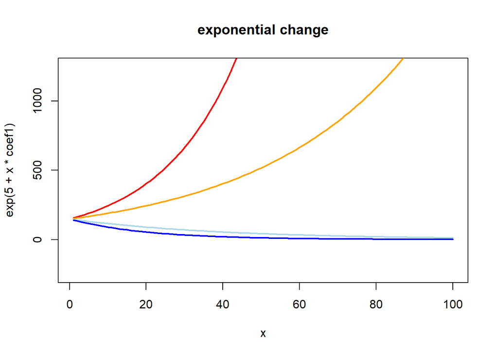

```r
x <- 1:100
coef1 <- 0.05
coef2 <- 0.025
coef3 <- -0.025
coef4 <- -0.05

plot(x,exp(5+x*coef1),type='l',ylim=c(-250,1250),lwd=2,col='red',main='exponential change')
lines(x,exp(5+x*coef2),lwd=2,col='orange')
lines(x,exp(5+x*coef3),lwd=2,col='lightblue')
lines(x,exp(5+x*coef4),lwd=2,col='blue')
```

As you can see in the code, the slope coefficients are 0.05, 0.025, and two negative slopes of the same magnitude, namely -0.025 and -0.05. The negative slopes are do not result in massive changes over time and in fact seem to reach a horizontal asymptote after a while. The positive slopes however increase very strongly (and will eventually appear to reach a vertical asymptote). The story is similar for the power5 link function, though when used in a regression it does attenuate the trend a bit more.

For the forecasting of cancer incidence, it is unlikely that an exponential growth is realistic. Normally, in etiological processes, exponential growth occurs when a process strengthens itself. But with cancer incidence, this is unlikely to be true. The log-link (or power5 link) is assumed because it ensures that incidence will never be predicted to be negative. However, something that is linear on the log scale will be multiplicative when transformed back to the interpretative scale. That is,

$ ^{x1+x2+x3} = e^{x1} e^{x2} e^{x3} $

This is especially bad because, even when the true DGP is linear on the log scale, due to the issue described as problem #1, we might not find the true linear trend when using APCMC models. We might find a trend that is far more positive. Fortunately, leave-future-out validation using the multiAPCMC package will get you quite far. You may have noticed that both the Nordpred software as well as the multiAPCMC package allow you to use a ‘cuttrend’ parameter. This parameter helps attenuate the explosive increase. You may have noticed that I almost never use the cuttrend parameter when using multiAPCMC. I think this is a testament to the utility of leave-future-out validation. However, even with multiAPCMC, explosive (or at least ‘strong’) increase could occur. So I am still not 100% happy. I think we can do better.

Let’s generate some APC data with a positive trend and check the forecasted slope.

```r
# simulation example, where 'true' effects are known
set.seed(2)
a <- 0:85
p <- 1990:2020
f <- data.frame(expand.grid(a,p))
names(f) <- c('Age','Period')
f$Cohort <- f$Period - f$Age
# set age period and cohort effects
# (we will use a log-link now, but let's assume a constant offset: i.e. no offset)
peff <- c(0.5,seq(1,1.7,length.out=30))+rnorm(31,0,0.25)
peff <- ifelse(peff < 0,0,peff)
f$aff <- log(f$Age*0.010 + f$Age^2*0.010 - f$Age^3*0.00010+0.001)
f$peff <- log(rep(peff,each=length(a)))
f$ceff <- 15*cos((f$Cohort-2000)/250)-13.8
# add them together with random error to produce y:
f$cases <- rpois(length(f$aff),exp((f$aff + f$peff + f$ceff)))
fc <- f
fc$Cohort <- fc$aff <- fc$peff <- fc$ceff <- NULL
fc$PY <- 1

fitlist <- multiAPCMC.multifit(data=fc,
                               startestage=5,
                               vec.link=c('log','power5'),
                               vec.noperiod=31,
                               vec.refper='extremes',
                               vec.refcoh='outer',
                               family='poisson',
                               nomodelmax=1024)
```

```
## [1] "fitting 2 APCMC models"
```

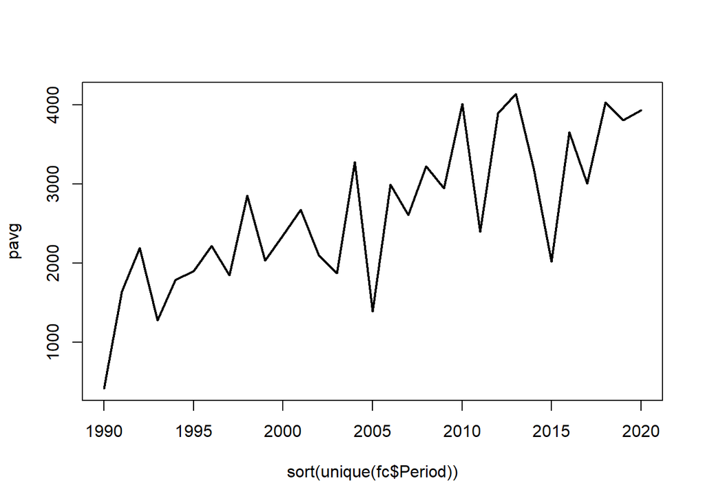

```r
fit.log <- fitlist$np.est[[1]][[1]][[1]][[1]]
fit.p5 <- fitlist$np.est[[2]][[1]][[1]][[1]]

# let's check the time-trend in the data that we analysed
pavg <- NULL
for(p in sort(unique(fc$Period))) {pavg[p-1989] <- sum(fc$cases[fc$Period==p])}
plot(sort(unique(fc$Period)), pavg,type='l',lwd=2)
```

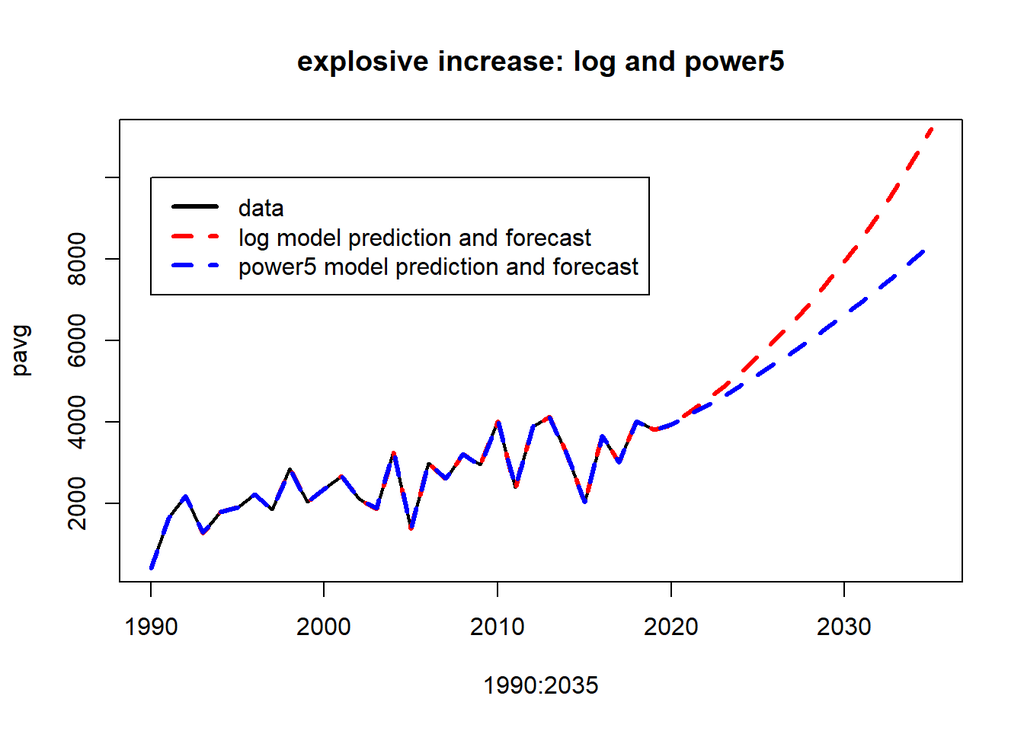

```r
pavg <- c(pavg,rep(NA,15))

# now let's extrapolate forward by 15 years
# we will make a dataset with the older timerange plus data for the next 15 years
a <- 0:85
p <- 2021:2035
fc.fut10 <- data.frame(expand.grid(a,p))
names(fc.fut10) <- c('Age','Period')
fc.fut10$PY <- 1
years <- 1990:2035

plot(1990:2035, pavg, type='l',lwd=2, ylim=c(500,11000),main='explosive increase: log and power5')
pred.log <- multiAPCMC.singlepred(multiAPCMC.singlefit.object=fit.log,
                    futuredata=fc.fut10,
                    noproj=length(p),
                    cuttrend=rep(0,15))
pred.p5 <- multiAPCMC.singlepred(multiAPCMC.singlefit.object=fit.p5,
                    futuredata=fc.fut10,
                    noproj=length(p),
                    cuttrend=rep(0,15))
incyear.pred.log <- multiAPCMC.predsummary(years,pred.log)
incyear.pred.p5 <- multiAPCMC.predsummary(years,pred.p5)
lines(years,incyear.pred.log$pred, col='red', lty=2,lwd=3)
lines(years,incyear.pred.p5$pred, col='blue', lty=2,lwd=3)
legend(1990,10000,legend=c('data','log model prediction and forecast', 'power5 model prediction and forecast'),lty=c(1,2,2,2),col=c('black','red','blue'),lwd=3)
```

This trend increase is potentially too strong to be realistic. Note that I did cheat a little bit here: I created it by abusing the ‘extremes’ constraint on period and making sure the initial data point is lower than it should be. As said before: this will likely be solved by trying many different model specifications with leave-future-out validation. We’d likely just go with an ‘outer’ constraints instead. However, let’s explore ways to attenuate this trend anyway.